# Menú

### Exploración de los Datos

#### Carga Datos

```python
df = pd.read_csv('../turnover.csv')
df.head(5)
```

|  | department | promoted | review | projects | salary | tenure | satisfaction | bonus | avg_hrs_month | left |
| --- | --- | --- | --- | --- | --- | --- | --- | --- | --- | --- |
| 0 | engineering | 0 | 0.467499 | 3 | medium | 4 | 0.829581 | 0 | 178.011622 | no |
| 1 | retail | 0 | 0.640763 | 4 | medium | 6 | 0.626555 | 0 | 182.609830 | no |
| 2 | engineering | 0 | 0.726654 | 4 | medium | 5 | 0.491993 | 0 | 179.829020 | no |
| 3 | engineering | 0 | 0.674880 | 3 | high | 6 | 0.407666 | 0 | 181.973226 | no |
| 4 | operations | 0 | 0.805861 | 4 | medium | 4 | 0.448412 | 1 | 175.680149 | no |

```python
print(f"department: {df['department'].unique().shape} -----------------> Categorica Nominal") # Categorica Nominal
print(f"promoted: {df['promoted'].unique()} -----------------> Categorica Nominal. Binaria") # Categorica Nominal. Binaria ---------> pasarla a codigo disyuntivo
print(f"review: {df['review'].unique().shape} -----------------> Numerica Continua") # Numerica Continua
print(f"projects: {df['projects'].unique()} -----------------> Numerica Discreta") # Numerica Discreta
print(f"salary: {df['salary'].unique()} -----------------> Categorica Ordinal") # Categorica Ordinal
print(f"tenure: {df['tenure'].unique()} -----------------> Numerica Discreta")# Numerica Discreta
print(f"satisfaction: {df['satisfaction'].unique().shape} -----------------> Numerica Continua") # Numerica Continua
print(f"bonus: {df['bonus'].unique()} -----------------> Categorica binaria") # Categorica binaria ------------> pasarla a codigo disyuntivo
print(f"avg_hrs_month: {df['avg_hrs_month'].unique().shape} -----------------> Numerica Continua") # Numerica Continua
print(f"left: {df['left'].unique()} -----------------> target") # target
```

```
department: (10,) -----------------> Categorica Nominal
promoted: [0 1] -----------------> Categorica Nominal. Binaria
review: (429,) -----------------> Numerica Continua
projects: [3 4 2 5] -----------------> Numerica Discreta
salary: ['medium' 'high' 'low'] -----------------> Categorica Ordinal
tenure: [ 4  6  5  3  8  7  9 10] -----------------> Numerica Discreta
satisfaction: (429,) -----------------> Numerica Continua
bonus: [0 1] -----------------> Categorica binaria
avg_hrs_month: (429,) -----------------> Numerica Continua
left: ['no' 'yes'] -----------------> target
```

```python
df.info()
```

```
<class 'pandas.core.frame.DataFrame'>
RangeIndex: 429 entries, 0 to 428
Data columns (total 10 columns):
 #   Column         Non-Null Count  Dtype
---  ------         --------------  -----
 0   department     429 non-null    object
 1   promoted       429 non-null    int64
 2   review         429 non-null    float64
 3   projects       429 non-null    int64
 4   salary         429 non-null    object
 5   tenure         429 non-null    int64
 6   satisfaction   429 non-null    float64
 7   bonus          429 non-null    int64
 8   avg_hrs_month  429 non-null    float64
 9   left           429 non-null    object
dtypes: float64(3), int64(4), object(3)
memory usage: 33.6+ KB
```

```python
df.isnull().sum()
```

```
department       0
promoted         0
review           0
projects         0
salary           0
tenure           0
satisfaction     0
bonus            0
avg_hrs_month    0
left             0
dtype: int64
```

#### Transformación de datos

```python
df_cod = df.copy()
df_cod[['promoted_yes','promoted_no']] = pd.get_dummies(df_cod['promoted'], dtype=int) #  1: Sí, 0:No.
df_cod[['bonus_yes','bonus_no']] = pd.get_dummies(df_cod['bonus'], dtype=int) #  1: Sí, 0:No.
df_cod.head(5)
df_cod = df_cod.drop(columns=['promoted', 'bonus'])
df_cod.head(5)
```

|  | department | review | projects | salary | tenure | satisfaction | avg_hrs_month | left | promoted_yes | promoted_no | bonus_yes | bonus_no |
| --- | --- | --- | --- | --- | --- | --- | --- | --- | --- | --- | --- | --- |
| 0 | engineering | 0.467499 | 3 | medium | 4 | 0.829581 | 178.011622 | no | 1 | 0 | 1 | 0 |
| 1 | retail | 0.640763 | 4 | medium | 6 | 0.626555 | 182.609830 | no | 1 | 0 | 1 | 0 |
| 2 | engineering | 0.726654 | 4 | medium | 5 | 0.491993 | 179.829020 | no | 1 | 0 | 1 | 0 |
| 3 | engineering | 0.674880 | 3 | high | 6 | 0.407666 | 181.973226 | no | 1 | 0 | 1 | 0 |
| 4 | operations | 0.805861 | 4 | medium | 4 | 0.448412 | 175.680149 | no | 1 | 0 | 0 | 1 |

```python
df_cod['department'] = df_cod['department'].astype('category')
df_cod['promoted_yes'] = df_cod['promoted_yes'].astype('category')
df_cod['promoted_no'] = df_cod['promoted_no'].astype('category')
df_cod['bonus_yes'] = df_cod['bonus_yes'].astype('category')
df_cod['bonus_no'] = df_cod['bonus_no'].astype('category')
df_cod['salary'] = df_cod['salary'].astype('category')
df_cod.info()
```

```
<class 'pandas.core.frame.DataFrame'>
RangeIndex: 429 entries, 0 to 428
Data columns (total 12 columns):
 #   Column         Non-Null Count  Dtype
---  ------         --------------  -----
 0   department     429 non-null    category
 1   review         429 non-null    float64
 2   projects       429 non-null    int64
 3   salary         429 non-null    category
 4   tenure         429 non-null    int64
 5   satisfaction   429 non-null    float64
 6   avg_hrs_month  429 non-null    float64
 7   left           429 non-null    object
 8   promoted_yes   429 non-null    category
 9   promoted_no    429 non-null    category
 10  bonus_yes      429 non-null    category
 11  bonus_no       429 non-null    category
dtypes: category(6), float64(3), int64(2), object(1)
memory usage: 23.7+ KB
```

#### Distribución de Variable a Predecir

```python
def distribucion_variable_predecir_cat(data:pd.DataFrame, variable_predict:str):
  conteo     = data[variable_predict].value_counts()
  valores    = conteo.to_list()
  categorias = conteo.index.to_list()
  titulo     = "Distribución de la variable %s" % variable_predict

  fig, ax = plt.subplots()
  ax.bar(categorias, valores)

  ax.set_ylabel(variable_predict)
  ax.set_title(titulo)

  for i, valor in enumerate(valores):
    porc = round(valor / sum(valores) * 100, 2)
    text = str(valor) + "\n" + str(porc) + "%"
    ax.text(i, valor * 0.45, text, color='white', ha='center', fontsize=10)

  return(fig)
```

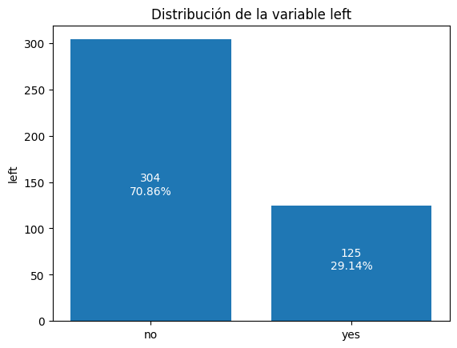

```python
distribucion_variable_predecir_cat(df_cod, 'left')
plt.show()
```

#### Poder Predictivo

```python
def poder_predictivo_numerica(data:pd.DataFrame, var:str, variable_predict:str):
  g = sns.FacetGrid(data, hue = variable_predict, height = 4, aspect = 1.8)
  g = g.map(sns.kdeplot, var, fill = True)
  g = g.add_legend()

  g.set_ylabels("Densidad")

  return(g)
```

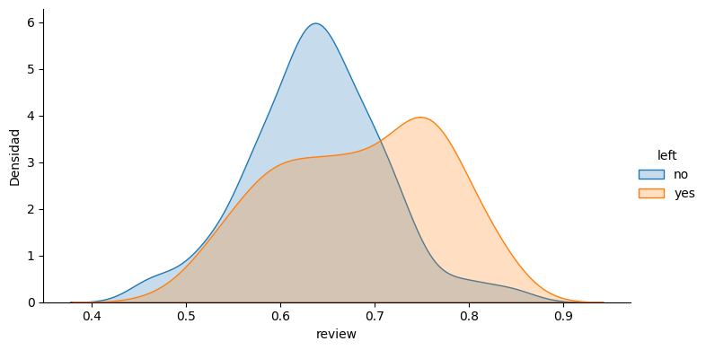

```python
fig = poder_predictivo_numerica(df, 'review', 'left')
plt.show()
```

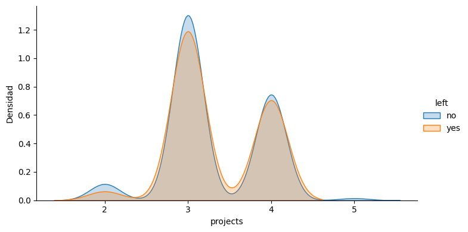

```python
fig = poder_predictivo_numerica(df, 'projects', 'left')
plt.show()
```

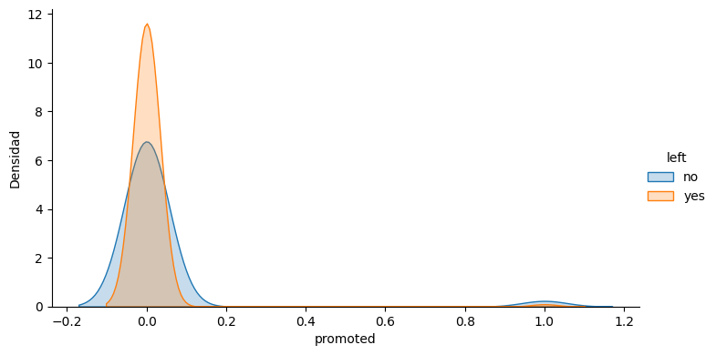

```python
fig = poder_predictivo_numerica(df, 'promoted', 'left')
plt.show()
```

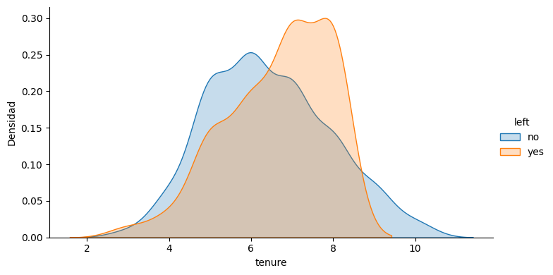

```python
fig = poder_predictivo_numerica(df, 'tenure', 'left')
plt.show()
```

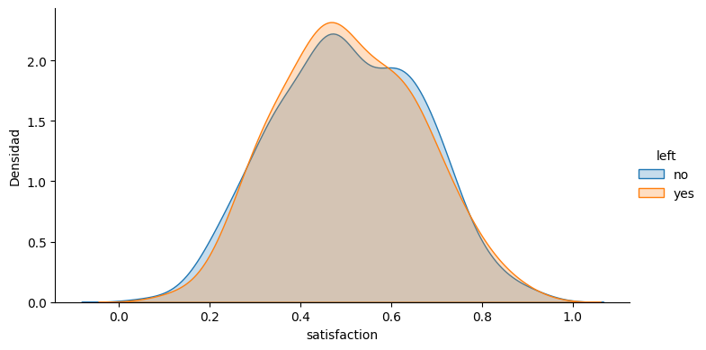

```python
fig = poder_predictivo_numerica(df, 'satisfaction', 'left')
plt.show()
```

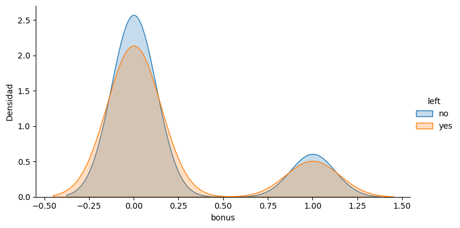

```python
fig = poder_predictivo_numerica(df, 'bonus', 'left')
plt.show()
```

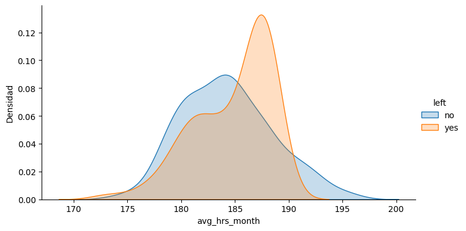

```python
fig = poder_predictivo_numerica(df, 'avg_hrs_month', 'left')
plt.show()
```

```python
# Clasificación de variables entre categóricas y númericas
var_categorical = 'department', 'salary', 'bonus_yes', 'bonus_no', 'promoted_yes', 'promoted_no'
var_numerical = 'review', 'projects', 'tenure', 'satisfaction', 'avg_hrs_month'

labels = ['no', 'yes'] # de target
```

### Division datos (X|y)

```python
X = df_cod.drop(columns=['left'])
print(f"X:\n{X.head(3)}")

y = df_cod['left'].to_numpy()
print(f"\ny:\n{y[:6]}")
```

```
X:
    department    review  projects  salary  tenure  satisfaction  \
0  engineering  0.467499         3  medium       4      0.829581
1       retail  0.640763         4  medium       6      0.626555
2  engineering  0.726654         4  medium       5      0.491993

   avg_hrs_month promoted_yes promoted_no bonus_yes bonus_no
0     178.011622            1           0         1        0
1     182.609830            1           0         1        0
2     179.829020            1           0         1        0

y:
['no' 'no' 'no' 'no' 'no' 'no']
```

### Preprocesamiento

```python
preprocesamiento = ColumnTransformer(
  transformers=[
    ('cat', OneHotEncoder(sparse_output = False), var_categorical),
    ('num', StandardScaler(), var_numerical)
  ]
)
```

```python
# def indices_general(MC, nombres = None):
#   precision_global = np.sum(MC.diagonal()) / np.sum(MC)
#   error_global     = 1 - precision_global
#   precision_categoria  = pd.DataFrame(MC.diagonal()/np.sum(MC,axis = 1)).T
#   if nombres!=None:
#     precision_categoria.columns = nombres

#   return {"Matriz de Confusión":MC,
#           "Precisión Global":   precision_global,
#           "Error Global":       error_global,
#           "Precisión por categoría":precision_categoria}
```

## Parte 1

- a) El objetivo de este ejercicio es comparar todos los métodos de clasificación vistos en el curso con esta tabla de datos. Para esto, genere una `Validación Cruzada` con **10 grupos** para los métodos `SVM`, `KNN`, `Árboles`, `Bosques`, `ADA Boosting`, `eXtreme Gradient Boosting`, `Bayes`, `LDA`, y `QDA` (en teoría se deberían calibrar todos los métodos).

↑ Volver al Menú

#### **SupportVectorMachine para Clasificación**

```python
y_vec  = np.asarray(y).ravel()
clases = np.unique(y_vec)

kfold = StratifiedKFold(n_splits=10, shuffle=True)

mc_sigmoid = np.zeros((len(clases), len(clases)), dtype=int)
mc_rbf     = np.zeros_like(mc_sigmoid)
mc_poly    = np.zeros_like(mc_sigmoid)

y_real_svm = []
prob_sigmoid = []
prob_rbf = []
prob_poly = []

for train_idx, test_idx in kfold.split(X, y_vec):
    X_tr, X_te = X.iloc[train_idx], X.iloc[test_idx]
    y_tr, y_te = y_vec[train_idx],  y_vec[test_idx]

    y_real_svm.extend(y_te)

    # ===== sigmoid =====
    modelo_sigmoid = Pipeline(steps=[
        ('preprocesador', preprocesamiento),
        ('clasificador', SVC(kernel='sigmoid', gamma='scale', probability=True))
    ])
    modelo_sigmoid.fit(X_tr, y_tr)
    mc_sigmoid += confusion_matrix(y_te, modelo_sigmoid.predict(X_te), labels=clases)
    prob_sigmoid.extend(modelo_sigmoid.predict_proba(X_te)[:, 1])

    # ===== rbf =====
    modelo_rbf = Pipeline(steps=[
        ('preprocesador', preprocesamiento),
        ('clasificador', SVC(kernel='rbf', gamma='scale', probability=True))
    ])
    modelo_rbf.fit(X_tr, y_tr)
    mc_rbf += confusion_matrix(y_te, modelo_rbf.predict(X_te), labels=clases)
    prob_rbf.extend(modelo_rbf.predict_proba(X_te)[:, 1])

    # ===== poly =====
    modelo_poly = Pipeline(steps=[
        ('preprocesador', preprocesamiento),
        ('clasificador', SVC(kernel='poly', gamma='scale', probability=True))
    ])
    modelo_poly.fit(X_tr, y_tr)
    mc_poly += confusion_matrix(y_te, modelo_poly.predict(X_te), labels=clases)
    prob_poly.extend(modelo_poly.predict_proba(X_te)[:, 1])


# print(f"mc_sigmoid:\n{mc_sigmoid}")
# print(f"mc_rbf:\n{mc_rbf}")
# print(f"mc_poly:\n{mc_poly}")

lista_mc_modelo_svm = [mc_sigmoid, mc_rbf, mc_poly]
lista_param_svm = [modelo_sigmoid, modelo_rbf, modelo_poly]
```

##### Evaluación SVM

```python
# # Classifier errors
# def metricas_errores(modelo, indices, corte=0.5):
#     probabilidad = modelo.predict_proba(X_te)[:, 1]
#     prediccion = np.where(probabilidad > corte, "yes", "no")

#     matrix = confusion_matrix(y_te, prediccion)
#     VN = matrix[0][0]
#     FP = matrix[0][1]
#     FN = matrix[1][0]
#     VP = matrix[1][1]

#     precision_global = (VN + VP) / (VN + FP + FN + VP)
#     error_global = 1 - precision_global
#     sensibilidad = VP / (FN + VP) #recall_yes
#     # precision = VP / (VP + FP)
#     especificidad = VN / (VN + FP) #recall_no

#     # métricas por clase (recall por categoría)
#     # recall_no  = VN / (VN + FP)   # especificidad
#     # recall_yes = VP / (VP + FN)   # sensibilidad

#     precision_por_categoria = pd.DataFrame(
#         [[especificidad, sensibilidad]], # no, yes
#         columns=["no", "yes"]
#     )

#     return {
#         'matriz_de_confusion': matrix,
#         'precision_global': precision_global,
#         'error_global': error_global,
#         "precision_por_categoria": precision_por_categoria
#         # 'precision_positiva': sensibilidad,
#         # 'precision_negativa': especificidad
#     }

# # metricas_errores(modelo_poly, indices_poly )#, corte=0.5)



# def indices_general(MC, nombres = None):
#   precision_global = np.sum(MC.diagonal()) / np.sum(MC)
#   error_global     = 1 - precision_global
#   precision_categoria  = pd.DataFrame(MC.diagonal()/np.sum(MC,axis = 1)).T
#   if nombres!=None:
#     precision_categoria.columns = nombres

#   return {"Matriz de Confusión":MC,
#           "Precisión Global":   precision_global,
#           "Error Global":       error_global,
#           "Precisión por categoría":precision_categoria}
```

```python
def metricas_errores(mc, nombres = None):
    # probabilidad = modelo.predict_proba(X_te)[:, 1]
    # prediccion = np.where(probabilidad > corte, "yes", "no")

    matrix = mc
    VN = matrix[0][0]
    FP = matrix[0][1]
    FN = matrix[1][0]
    VP = matrix[1][1]

    precision_global = (VN + VP) / (VN + FP + FN + VP)
    error_global = 1 - precision_global
    sensibilidad = VP / (FN + VP) #recall_yes
    especificidad = VN / (VN + FP) #recall_no
    # precision = VP / (VP + FP)

    precision_por_categoria = pd.DataFrame(
        [[especificidad, sensibilidad]], # no, yes
        columns = nombres if nombres is not None else ["no", "yes"]
    )

    return {
        "Matriz de Confusión": matrix,
        "Precisión Global": precision_global,
        "Error Global": error_global,
        "Precisión por categoría": precision_por_categoria
        # 'precision_positiva': sensibilidad,
        # 'precision_negativa': especificidad
    }

    # return {"Matriz de Confusión": matrix,
    #     "Precisión Global":   precision_global,
    #     "Error Global":       error_global,
    #     "Precisión por categoría":precision_categoria}





# metricas_errores(modelo_poly, mc_poly)
```

```python
def metricas_manuales(labels, lista_mc_param_modelos, lista_param_modelos, nucleo = None):
    lista_indices = {}
    for i, l in enumerate(lista_mc_param_modelos):
        # indice = indices_general(l, labels)
        indice = metricas_errores(l, labels)

        if nucleo != None:
            clf = lista_param_modelos[i].named_steps['clasificador']
            nombre_del_nucleo_del_modelo = str(clf.get_params()[nucleo])
            nombre_completo_modelo = str(lista_param_modelos[i].named_steps['clasificador'].__class__.__name__) + ', ' + nucleo + ': ' + nombre_del_nucleo_del_modelo
            lista_indices[nombre_del_nucleo_del_modelo] = indice

        else:
            nombre_completo_modelo = str(lista_param_modelos[i].named_steps['clasificador'])
            lista_indices[nombre_completo_modelo] = indice


        # lista_indices[nombre_del_nucleo_del_modelo] = indice
        # simplificar y hacer un for
        print("============="*4)
        print("Modelo:", nombre_completo_modelo)
        print("============="*4)
        for k in indice:
            print("%s:\n%s\n" % (k, str(indice[k])))

    return lista_indices

# lista_mc_param_modelos = [mc_sigmoid, mc_rbf, mc_poly]
# lista_param_modelos = [modelo_sigmoid, modelo_rbf, modelo_poly]
indices_svm = metricas_manuales(labels,
                            lista_mc_modelo_svm,
                            lista_param_svm,
                            nucleo='kernel')

indices_sigmoid = indices_svm['sigmoid']
indices_rbf = indices_svm['rbf']
indices_poly = indices_svm['poly']
nombre_nucleos = ["sigmoid", "rbf", "poly"]
```

```
====================================================
Modelo: SVC, kernel: sigmoid
====================================================
Matriz de Confusión:
[[220  84]
 [105  20]]

Precisión Global:
0.5594405594405595

Error Global:
0.4405594405594405

Precisión por categoría:
         no   yes
0  0.723684  0.16

====================================================
Modelo: SVC, kernel: rbf
====================================================
Matriz de Confusión:
[[282  22]
 [ 74  51]]

Precisión Global:
0.7762237762237763

Error Global:
0.22377622377622375

Precisión por categoría:
         no    yes
0  0.927632  0.408

====================================================
Modelo: SVC, kernel: poly
====================================================
Matriz de Confusión:
[[276  28]
 [ 74  51]]

Precisión Global:
0.7622377622377622

Error Global:
0.23776223776223782

Precisión por categoría:
         no    yes
0  0.907895  0.408
```

##### Gráficos

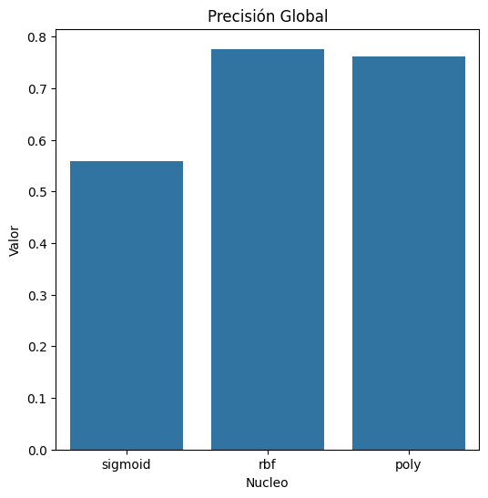

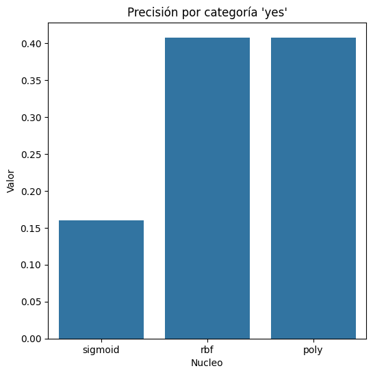

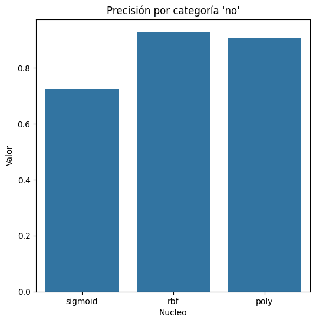

```python
def metricas_barchart(nombre_nucleos, lista_indices_param):
    valores_p_global = []
    valores_p_si = []
    valores_p_no = []
    for i, item in enumerate(lista_indices_param):
        valores_p_global = np.append(valores_p_global, lista_indices_param[i]['Precisión Global'])
        valores_p_si = np.append(valores_p_si, lista_indices_param[i]['Precisión por categoría']['yes'])
        valores_p_no = np.append(valores_p_no, lista_indices_param[i]['Precisión por categoría']['no'])


    ## Simplificar mas adelante
    fig, ax = plt.subplots(figsize = (6, 6))
    p_global = pd.DataFrame({
            'Nucleo' : nombre_nucleos,
            'Valor'  : valores_p_global
        })
    no_print = sns.barplot(x = 'Nucleo', y = 'Valor', data = p_global)
    no_print = plt.title("Precisión Global")
    plt.show()

    fig, ax = plt.subplots(figsize = (6, 6))
    p_si = pd.DataFrame({
            'Nucleo' : nombre_nucleos,
            'Valor'  : valores_p_si
        })
    no_print = sns.barplot(x = 'Nucleo', y = 'Valor', data = p_si)
    no_print = plt.title("Precisión por categoría 'yes'")
    plt.show()

    fig, ax = plt.subplots(figsize = (6, 6))
    p_no = pd.DataFrame({
            'Nucleo' : nombre_nucleos,
            'Valor'  : valores_p_no
        })
    no_print = sns.barplot(x = 'Nucleo', y = 'Valor', data = p_no)
    no_print = plt.title("Precisión por categoría 'no'")
    plt.show()

lista_indices_svm=[indices_sigmoid, indices_rbf, indices_poly]
metricas_barchart(nombre_nucleos, lista_indices_svm)
```

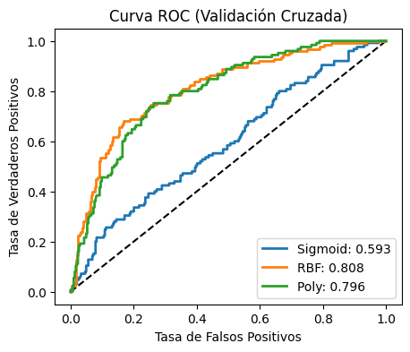

```python
def imprimir_ROC_cv(y_real, probs_dict):
    fig, ax = plt.subplots(figsize=(5, 4))
    ax.plot([0, 1], [0, 1], linestyle='dashed', color='black')


    for nombre, probs in probs_dict.items():
        fpr, tpr, _ = roc_curve(y_real, probs, pos_label='yes')
        area = roc_auc_score(y_real, probs)
        ax.plot(fpr, tpr, lw=2, label=f"{nombre}: {area:.3f}")

    ax.set_xlabel("Tasa de Falsos Positivos")
    ax.set_ylabel("Tasa de Verdaderos Positivos")
    ax.set_title("Curva ROC (Validación Cruzada)")
    ax.legend(loc="lower right")
    plt.show()

probs_modelos_svm = {
    'Sigmoid': prob_sigmoid,
    'RBF': prob_rbf,
    'Poly': prob_poly
}

imprimir_ROC_cv(y_real_svm, probs_modelos_svm)
```

##### Probabilidades de Corte

```python
def imp_umbral_corte(modelo, X_te, y_te, y_vec, corte = np.arange(0, 1, 0.1), nucleo = None):
    # nuclero: parametro del modelo que se quiere mostrar
    # corte: es mas dinamico para visualizar diferentes cortes.

    probabilidades = modelo.predict_proba(X_te)
    probabilidad_yes = probabilidades[:, 1]

    # Aplicamos una Regla de Decisión
    # corte = #np.arange(0, 1, 0.1)
    corte = np.round(corte, 4)
    lenght_corte = len(corte)
    tabla = []
    MC_por_corte = {}
    for c in corte:
        prediccion = np.where(probabilidad_yes > c, "yes", "no") #where hace un arreglo con asignaciones dependiendo de la condición.
        MC = confusion_matrix(y_te, prediccion)
        indices = metricas_errores(MC,
                                   list(np.unique(y_vec))
                                   )
        tabla = np.append(tabla,[ c, indices['Precisión Global'] ]) #corte, error global
        precision_categoria = indices['Precisión por categoría'].values.flatten()
        MC_por_corte[c] = MC
        tabla = np.append(tabla,precision_categoria)



    if nucleo != None:
        clf = modelo.named_steps['clasificador']
        nombre_del_nucleo_del_modelo = str(clf.get_params()[nucleo])
        nombre_completo_modelo = str(nucleo +": " + nombre_del_nucleo_del_modelo)
        # lista_indices[nombre_del_nucleo_del_modelo] = indice

    else:
        nombre_completo_modelo = ': '+str(modelo.named_steps['clasificador'])
        # lista_indices[nombre_completo_modelo] = indice

    # clf = modelo.named_steps['clasificador']
    # nombre_del_nucleo_del_modelo = clf.get_params()[nucleo]

    # nombre_del_nucleo_del_modelo = modelo['clasificador'].kernel
    tabla1 = np.array(tabla).reshape(lenght_corte,4)
    print("====================="*2)
    print("Probabilidad de Corte de", nombre_completo_modelo)
    print("====================="*2)
    columnas =["Corte", "PG", "PN", "PP"]
    df = pd.DataFrame(tabla1, columns = columnas)
    df.Corte = ["%.2f" % x for x in df.Corte] #Se pasa el corte a un string
    # df
    print(df)
    # return MC_por_corte
```

```python
# imp_umbral_corte(modelo_sigmoid, X_te, y_te, y_vec, "kernel")
imp_umbral_corte(modelo_poly, X_te, y_te, y_vec, nucleo="kernel")
# imp_umbral_corte(modelo_poly, X_te, y_te, y_vec, "kernel")
```

```
==========================================
Probabilidad de Corte de kernel: poly
==========================================
  Corte        PG        PN        PP
0  0.00  0.285714  0.000000  1.000000
1  0.10  0.452381  0.233333  1.000000
2  0.20  0.619048  0.500000  0.916667
3  0.30  0.714286  0.700000  0.750000
4  0.40  0.785714  0.833333  0.666667
5  0.50  0.738095  0.866667  0.416667
6  0.60  0.714286  0.900000  0.250000
7  0.70  0.738095  0.933333  0.250000
8  0.80  0.714286  0.966667  0.083333
9  0.90  0.690476  0.966667  0.000000
```

```python
imp_umbral_corte(modelo_poly, X_te, y_te, y_vec, corte = np.arange(0.3, 0.4, 0.01), nucleo="kernel")
```

```
==========================================
Probabilidad de Corte de kernel: poly
==========================================
   Corte        PG        PN        PP
0   0.30  0.714286  0.700000  0.750000
1   0.31  0.714286  0.700000  0.750000
2   0.32  0.714286  0.700000  0.750000
3   0.33  0.714286  0.700000  0.750000
4   0.34  0.785714  0.800000  0.750000
5   0.35  0.785714  0.800000  0.750000
6   0.36  0.785714  0.833333  0.666667
7   0.37  0.785714  0.833333  0.666667
8   0.38  0.785714  0.833333  0.666667
9   0.39  0.785714  0.833333  0.666667
10  0.40  0.785714  0.833333  0.666667
```

#### Resultados

```python
def dataframe_desde_indices(indices, nucleo):
    """
    Parámetros:
    -----------
    indices : list of dict
        Lista de diccionarios devueltos por metricas_errores()
    nucleo : list
        Nombres de los modelos correspondientes

    Retorna:
    --------
    pd.DataFrame ordenado por Precisión Global
    """

    resultados = []
    for indices, nombre in zip(indices, nucleo):
        # Extraer directamente de tu estructura existente
        pg = indices['Precisión Global']
        eg = indices['Error Global']

        # Tu 'Precisión por categoría' es un DataFrame con una fila
        precision_cat = indices['Precisión por categoría']

        # Obtener valores (asumiendo estructura ['no', 'yes'])
        # Primera columna: 'no' (PN), Segunda columna: 'yes' (PP)
        valores = precision_cat.values.flatten()

        # Verificar que tenemos al menos 2 valores
        if len(valores) >= 2:
            pn = valores[0]  # Primera columna = 'no' = PN
            pp = valores[1]  # Segunda columna = 'yes' = PP
        else:
            pn = 0
            pp = 0

        resultados.append({
            'Modelo': nombre,
            'Precisión Global': pg,
            'Error Global': eg,
            'Precisión Positiva (PP)': pp,
            'Precisión Negativa (PN)': pn
        })

    df = pd.DataFrame(resultados)
    df = df.sort_values('Precisión Global', ascending=False).reset_index(drop=True)

    return df

# def formatear_resultados(df_resultados, decimales=2):
#     """
#     Formatea el DataFrame para mostrar porcentajes legibles
#     Mantiene los valores numéricos originales en atributos
#     """
#     df_formateado = df_resultados.copy()

#     columnas_porcentaje = ['Precisión Global', 'Error Global',
#                           'Precisión Positiva (PP)', 'Precisión Negativa (PN)']

#     # Guardar valores originales como atributos
#     df_formateado.attrs['valores_originales'] = df_resultados[columnas_porcentaje].copy()

#     # Formatear como porcentaje
#     for col in columnas_porcentaje:
#         if col in df_formateado.columns:
#             df_formateado[col] = df_formateado[col].apply(
#                 lambda x: f"{x*100:.{decimales}f}%"
#             )

#     return df_formateado

df_svm_indices = dataframe_desde_indices(
    indices=[indices_sigmoid, indices_rbf, indices_poly],
    nucleo=['SVM_sigmoid', 'SVM_rbf', 'SVM_poly']
)

df_svm_indices
```

|  | Modelo | Precisión Global | Error Global | Precisión Positiva (PP) | Precisión Negativa (PN) |
| --- | --- | --- | --- | --- | --- |
| 0 | SVM_rbf | 0.776224 | 0.223776 | 0.408 | 0.927632 |
| 1 | SVM_poly | 0.762238 | 0.237762 | 0.408 | 0.907895 |
| 2 | SVM_sigmoid | 0.559441 | 0.440559 | 0.160 | 0.723684 |

#### **KNeighborsClassifier**

```python
y_vec  = np.asarray(y).ravel()
clases = np.unique(y_vec)

kfold = StratifiedKFold(n_splits=10, shuffle=True)

mc_ball_tree = np.zeros((len(clases), len(clases)), dtype=int)
mc_kd_tree   = np.zeros_like(mc_ball_tree)
mc_brute     = np.zeros_like(mc_ball_tree)

y_real_knn = []
prob_ball = []
prob_kd = []
prob_brute = []
for train_idx, test_idx in kfold.split(X, y_vec):
    X_tr, X_te = X.iloc[train_idx], X.iloc[test_idx]
    y_tr, y_te = y_vec[train_idx],  y_vec[test_idx]


    y_real_knn.extend(y_te)

    # ===== ball_tree =====
    modelo_ball_tree = Pipeline(steps=[
        ('preprocesador', preprocesamiento),
        ('clasificador', KNeighborsClassifier(n_neighbors=15, algorithm='ball_tree'))
    ])
    modelo_ball_tree.fit(X_tr, y_tr)
    mc_ball_tree += confusion_matrix(y_te, modelo_ball_tree.predict(X_te), labels=clases)
    prob_ball.extend(modelo_ball_tree.predict_proba(X_te)[:, 1])

    # ===== kd_tree =====
    modelo_kd_tree = Pipeline(steps=[
        ('preprocesador', preprocesamiento),
        ('clasificador', KNeighborsClassifier(n_neighbors=15, algorithm='kd_tree'))
    ])
    modelo_kd_tree.fit(X_tr, y_tr)
    mc_kd_tree += confusion_matrix(y_te, modelo_kd_tree.predict(X_te), labels=clases)
    prob_kd.extend(modelo_kd_tree.predict_proba(X_te)[:, 1])

    # ===== brute =====
    modelo_brute = Pipeline(steps=[
        ('preprocesador', preprocesamiento),
        ('clasificador', KNeighborsClassifier(n_neighbors=15, algorithm='brute'))
    ])
    modelo_brute.fit(X_tr, y_tr)
    mc_brute += confusion_matrix(y_te, modelo_brute.predict(X_te), labels=clases)
    prob_brute.extend(modelo_brute.predict_proba(X_te)[:, 1])


lista_mc_modelo_knn = [mc_ball_tree, mc_kd_tree, mc_brute]
lista_param_knn = [modelo_ball_tree, modelo_kd_tree, modelo_brute]
```

##### Evaluación KNN

```python
indices_knn = metricas_manuales(labels,
                            lista_mc_modelo_knn,
                            lista_param_knn,
                            nucleo='algorithm')

indices_ball_tree = indices_knn['ball_tree']
indices_kd_tree = indices_knn['kd_tree']
indices_brute = indices_knn['brute']

nombre_nucleos_knn = ["ball_tree", "kd_tree", "brute"]
```

```
====================================================
Modelo: KNeighborsClassifier, algorithm: ball_tree
====================================================
Matriz de Confusión:
[[290  14]
 [ 79  46]]

Precisión Global:
0.7832167832167832

Error Global:
0.21678321678321677

Precisión por categoría:
         no    yes
0  0.953947  0.368

====================================================
Modelo: KNeighborsClassifier, algorithm: kd_tree
====================================================
Matriz de Confusión:
[[290  14]
 [ 79  46]]

Precisión Global:
0.7832167832167832

Error Global:
0.21678321678321677

Precisión por categoría:
         no    yes
0  0.953947  0.368

====================================================
Modelo: KNeighborsClassifier, algorithm: brute
====================================================
Matriz de Confusión:
[[290  14]
 [ 79  46]]

Precisión Global:
0.7832167832167832

Error Global:
0.21678321678321677

Precisión por categoría:
         no    yes
0  0.953947  0.368
```

##### Gráficos

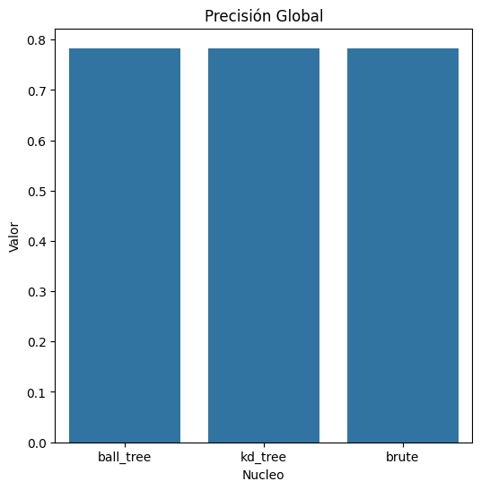

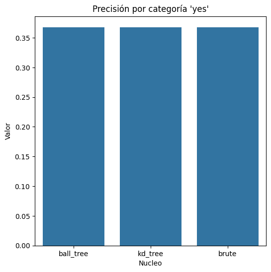

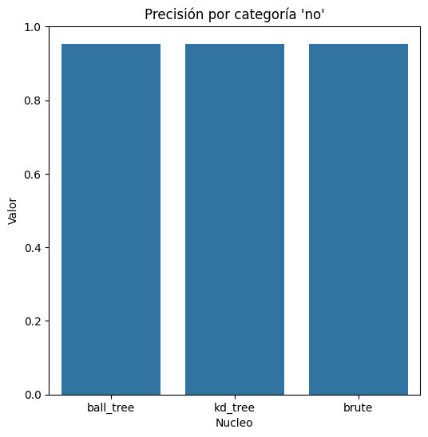

```python
lista_indices_knn = [indices_ball_tree, indices_kd_tree, indices_brute]
metricas_barchart(nombre_nucleos_knn,
                  lista_indices_knn)
```

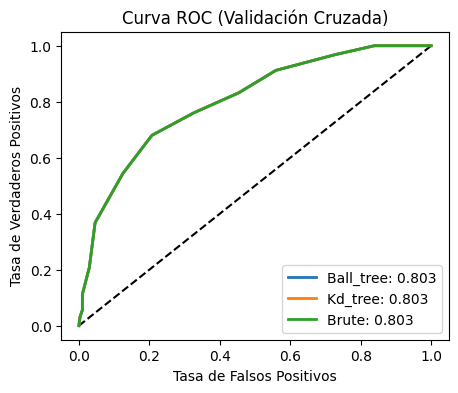

```python
probs_knn = {
    'Ball_tree': prob_ball,
    'Kd_tree': prob_kd,
    'Brute': prob_brute
}
imprimir_ROC_cv(y_real_knn, probs_knn)
```

##### Probabilidades de Corte

```python
imp_umbral_corte(modelo_ball_tree, X_te, y_te, y_vec, nucleo="algorithm") #, corte = np.arange(0.3, 0.4, 0.01))
```

```
==========================================
Probabilidad de Corte de algorithm: ball_tree
==========================================
  Corte        PG        PN        PP
0  0.00  0.428571  0.200000  1.000000
1  0.10  0.571429  0.400000  1.000000
2  0.20  0.714286  0.666667  0.833333
3  0.30  0.714286  0.733333  0.666667
4  0.40  0.714286  0.866667  0.333333
5  0.50  0.809524  1.000000  0.333333
6  0.60  0.738095  1.000000  0.083333
7  0.70  0.714286  1.000000  0.000000
8  0.80  0.714286  1.000000  0.000000
9  0.90  0.714286  1.000000  0.000000
```

```python
# imp_umbral_corte(modelo_ball_tree, X_te, y_te, y_vec, nucleo="algorithm", corte = np.arange(0.1, 0.2, 0.01))
```

#### Resultados

```python
df_knn_indices = dataframe_desde_indices(
    indices=[indices_ball_tree, indices_kd_tree, indices_brute],
    nucleo=['knn_ball_tree', 'knn_kd_tree', 'knn_brute']
)

df_knn_indices
```

|  | Modelo | Precisión Global | Error Global | Precisión Positiva (PP) | Precisión Negativa (PN) |
| --- | --- | --- | --- | --- | --- |
| 0 | knn_ball_tree | 0.783217 | 0.216783 | 0.368 | 0.953947 |
| 1 | knn_kd_tree | 0.783217 | 0.216783 | 0.368 | 0.953947 |
| 2 | knn_brute | 0.783217 | 0.216783 | 0.368 | 0.953947 |

#### **DecisionTreeClassifier**

```python
y_vec  = np.asarray(y).ravel()
clases = np.unique(y_vec)

kfold = StratifiedKFold(n_splits=10, shuffle=True)  # sin random_state

mc_gini_dtc     = np.zeros((len(clases), len(clases)), dtype=int)
mc_entropy_dtc  = np.zeros_like(mc_gini_dtc)
mc_log_loss_dtc = np.zeros_like(mc_gini_dtc)

y_real_dtc = []
prob_gini_dtc = []
prob_entropy_dtc = []
prob_log_loss_dtc = []
for train_idx, test_idx in kfold.split(X, y_vec):
  X_tr, X_te = X.iloc[train_idx], X.iloc[test_idx]
  y_tr, y_te = y_vec[train_idx],  y_vec[test_idx]

  y_real_dtc.extend(y_te)

  # gini
  modelo_gini_dtc = Pipeline(steps=[
    ('preprocesador', preprocesamiento),
    ('clasificador', DecisionTreeClassifier(criterion='gini', max_depth=4, min_samples_split=2, min_samples_leaf=2))
  ])
  modelo_gini_dtc.fit(X_tr, y_tr)
  mc_gini_dtc += confusion_matrix(y_te, modelo_gini_dtc.predict(X_te), labels=clases)
  prob_gini_dtc.extend(modelo_gini_dtc.predict_proba(X_te)[:, 1])

  # entropy
  modelo_entropy_dtc = Pipeline(steps=[
    ('preprocesador', preprocesamiento),
    ('clasificador', DecisionTreeClassifier(criterion='entropy', max_depth=4, min_samples_split=2, min_samples_leaf=2))
  ])
  modelo_entropy_dtc.fit(X_tr, y_tr)
  mc_entropy_dtc += confusion_matrix(y_te, modelo_entropy_dtc.predict(X_te), labels=clases)
  prob_entropy_dtc.extend(modelo_entropy_dtc.predict_proba(X_te)[:, 1])

  # log_loss
  modelo_log_loss_dtc = Pipeline(steps=[
    ('preprocesador', preprocesamiento),
    ('clasificador', DecisionTreeClassifier(criterion='log_loss', max_depth=4, min_samples_split=2, min_samples_leaf=2))
  ])
  modelo_log_loss_dtc.fit(X_tr, y_tr)
  mc_log_loss_dtc += confusion_matrix(y_te, modelo_log_loss_dtc.predict(X_te), labels=clases)
  prob_log_loss_dtc.extend(modelo_log_loss_dtc.predict_proba(X_te)[:, 1])
# mc_gini_dtc
# mc_entropy_dtc
# mc_log_loss_dtc

lista_mc_modelo_dtc = [mc_gini_dtc, mc_entropy_dtc, mc_log_loss_dtc]
lista_param_dtc = [modelo_gini_dtc, modelo_entropy_dtc, modelo_log_loss_dtc]
```

##### Evaluación DecisionTreeClassifier

```python
indices_dtc = metricas_manuales(labels,
                                lista_mc_modelo_dtc,
                                lista_param_dtc,
                                nucleo='criterion')

indices_gini_dtc = indices_dtc['gini']
indices_entropy_dtc = indices_dtc['entropy']
indices_log_loss_dtc = indices_dtc['log_loss']

nombre_nucleos_dtc = ["gini", "entropy", "log_loss"]
```

```
====================================================
Modelo: DecisionTreeClassifier, criterion: gini
====================================================
Matriz de Confusión:
[[285  19]
 [ 49  76]]

Precisión Global:
0.8414918414918415

Error Global:
0.15850815850815847

Precisión por categoría:
       no    yes
0  0.9375  0.608

====================================================
Modelo: DecisionTreeClassifier, criterion: entropy
====================================================
Matriz de Confusión:
[[284  20]
 [ 49  76]]

Precisión Global:
0.8391608391608392

Error Global:
0.16083916083916083

Precisión por categoría:
         no    yes
0  0.934211  0.608

====================================================
Modelo: DecisionTreeClassifier, criterion: log_loss
====================================================
Matriz de Confusión:
[[284  20]
 [ 49  76]]

Precisión Global:
0.8391608391608392

Error Global:
0.16083916083916083

Precisión por categoría:
         no    yes
0  0.934211  0.608
```

##### Gráficos

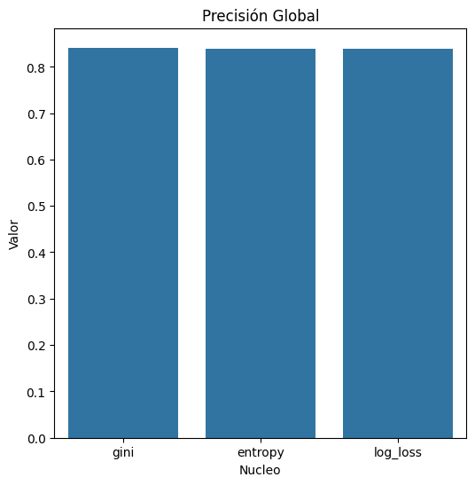

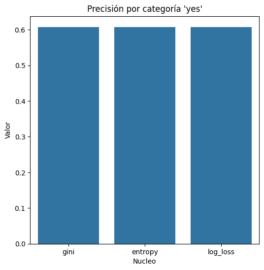

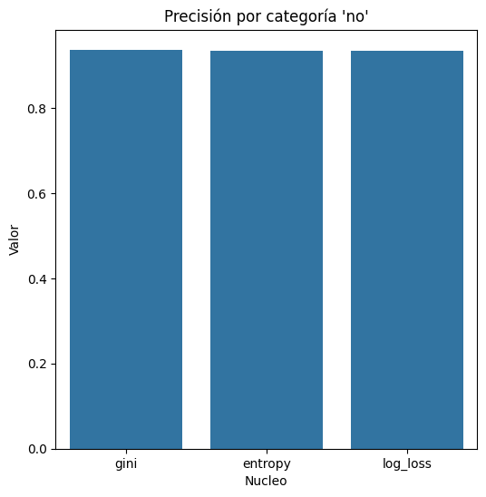

```python
lista_indices_dtc = [indices_gini_dtc, indices_entropy_dtc, indices_log_loss_dtc]
metricas_barchart(nombre_nucleos_dtc,
                  lista_indices_dtc)
```

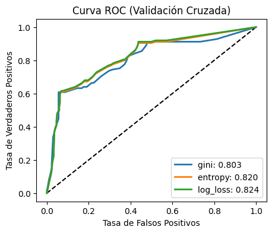

```python
probs_dtc = {
    'gini': prob_gini_dtc,
    'entropy': prob_entropy_dtc,
    'log_loss': prob_log_loss_dtc
}
imprimir_ROC_cv(y_real_dtc, probs_dtc)
```

##### Probabilidades de Corte

```python
# imp_umbral_corte(modelo_entropy_dtc, X_te, y_te, y_vec, nucleo="criterion") #, corte = np.arange(0.3, 0.4, 0.01))
# imp_umbral_corte(modelo_gini_dtc, X_te, y_te, y_vec, nucleo="criterion") #, corte = np.arange(0.3, 0.4, 0.01))
imp_umbral_corte(modelo_log_loss_dtc, X_te, y_te, y_vec, nucleo="criterion") #, corte = np.arange(0.3, 0.4, 0.01))
```

```
==========================================
Probabilidad de Corte de criterion: log_loss
==========================================
  Corte        PG        PN        PP
0  0.00  0.547619  0.433333  0.833333
1  0.10  0.690476  0.633333  0.833333
2  0.20  0.666667  0.633333  0.750000
3  0.30  0.880952  1.000000  0.583333
4  0.40  0.880952  1.000000  0.583333
5  0.50  0.880952  1.000000  0.583333
6  0.60  0.880952  1.000000  0.583333
7  0.70  0.880952  1.000000  0.583333
8  0.80  0.880952  1.000000  0.583333
9  0.90  0.785714  1.000000  0.250000
```

```python
imp_umbral_corte(modelo_log_loss_dtc, X_te, y_te, y_vec, nucleo="criterion", corte = np.arange(0.2, 0.3, 0.01))
```

```
==========================================
Probabilidad de Corte de criterion: log_loss
==========================================
  Corte        PG        PN        PP
0  0.20  0.666667  0.633333  0.750000
1  0.21  0.666667  0.633333  0.750000
2  0.22  0.666667  0.633333  0.750000
3  0.23  0.666667  0.633333  0.750000
4  0.24  0.666667  0.633333  0.750000
5  0.25  0.666667  0.633333  0.750000
6  0.26  0.761905  0.800000  0.666667
7  0.27  0.761905  0.800000  0.666667
8  0.28  0.761905  0.800000  0.666667
9  0.29  0.880952  1.000000  0.583333
```

#### Resultados

```python
df_dtc_indices = dataframe_desde_indices(
    indices=[indices_gini_dtc, indices_entropy_dtc, indices_log_loss_dtc],
    nucleo=['dtc_gini', 'dtc_entropy', 'dtc_log_loss']
)

df_dtc_indices
```

|  | Modelo | Precisión Global | Error Global | Precisión Positiva (PP) | Precisión Negativa (PN) |
| --- | --- | --- | --- | --- | --- |
| 0 | dtc_gini | 0.841492 | 0.158508 | 0.608 | 0.937500 |
| 1 | dtc_entropy | 0.839161 | 0.160839 | 0.608 | 0.934211 |
| 2 | dtc_log_loss | 0.839161 | 0.160839 | 0.608 | 0.934211 |

- Se utilizara el el algoritmo log_loss con el corte de probabilidad por 0.25.

#### **RandomForestClassifier**

```python
y_vec  = np.asarray(y).ravel()
clases = np.unique(y_vec)

kfold = StratifiedKFold(n_splits=10, shuffle=True)  # sin random_state

mc_gini     = np.zeros((len(clases), len(clases)), dtype=int)
mc_entropy  = np.zeros_like(mc_gini)
mc_log_loss = np.zeros_like(mc_gini)

y_real_rfc = []
prob_gini = []
prob_entropy = []
prob_log_loss = []
for train_idx, test_idx in kfold.split(X, y_vec):
  X_tr, X_te = X.iloc[train_idx], X.iloc[test_idx]
  y_tr, y_te = y_vec[train_idx],  y_vec[test_idx]

  y_real_rfc.extend(y_te)

  # gini
  modelo_gini = Pipeline(steps=[
    ('preprocesador', preprocesamiento),
    ('clasificador', RandomForestClassifier(n_estimators=21, criterion='gini'))
  ])
  modelo_gini.fit(X_tr, y_tr)
  mc_gini += confusion_matrix(y_te, modelo_gini.predict(X_te), labels=clases)
  prob_gini.extend(modelo_gini.predict_proba(X_te)[:, 1])

  # entropy
  modelo_entropy = Pipeline(steps=[
    ('preprocesador', preprocesamiento),
    ('clasificador', RandomForestClassifier(n_estimators=21, criterion='entropy'))
  ])
  modelo_entropy.fit(X_tr, y_tr)
  mc_entropy += confusion_matrix(y_te, modelo_entropy.predict(X_te), labels=clases)
  prob_entropy.extend(modelo_entropy.predict_proba(X_te)[:, 1])

  # log_loss
  modelo_log_loss = Pipeline(steps=[
    ('preprocesador', preprocesamiento),
    ('clasificador', RandomForestClassifier(n_estimators=21, criterion='log_loss'))
  ])
  modelo_log_loss.fit(X_tr, y_tr)
  mc_log_loss += confusion_matrix(y_te, modelo_log_loss.predict(X_te), labels=clases)
  prob_log_loss.extend(modelo_log_loss.predict_proba(X_te)[:, 1])
# mc_gini
# mc_entropy
# mc_log_loss

lista_mc_modelo_rfc = [mc_gini, mc_entropy, mc_log_loss]
lista_param_rfc = [modelo_gini, modelo_entropy, modelo_log_loss]
```

##### Evaluación RandomForestClassifier

```python
indices_rfc = metricas_manuales(labels,
                            lista_mc_modelo_rfc,
                            lista_param_rfc,
                            nucleo='criterion')

indices_gini = indices_rfc['gini']
indices_entropy = indices_rfc['entropy']
indices_log_loss = indices_rfc['log_loss']

nombre_nucleos_rfc = ["gini", "entropy", "log_loss"]
```

```
====================================================
Modelo: RandomForestClassifier, criterion: gini
====================================================
Matriz de Confusión:
[[281  23]
 [ 48  77]]

Precisión Global:
0.8344988344988346

Error Global:
0.16550116550116545

Precisión por categoría:
         no    yes
0  0.924342  0.616

====================================================
Modelo: RandomForestClassifier, criterion: entropy
====================================================
Matriz de Confusión:
[[285  19]
 [ 52  73]]

Precisión Global:
0.8344988344988346

Error Global:
0.16550116550116545

Precisión por categoría:
       no    yes
0  0.9375  0.584

====================================================
Modelo: RandomForestClassifier, criterion: log_loss
====================================================
Matriz de Confusión:
[[278  26]
 [ 54  71]]

Precisión Global:
0.8135198135198135

Error Global:
0.1864801864801865

Precisión por categoría:
         no    yes
0  0.914474  0.568
```

##### Gráficos

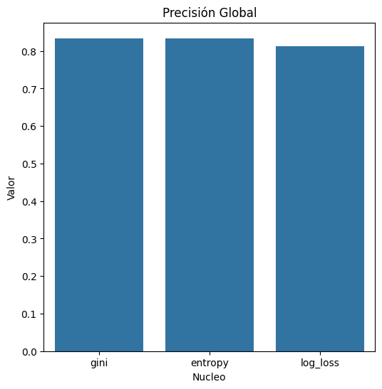

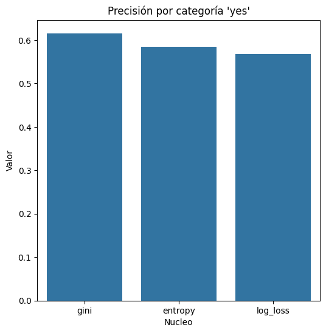

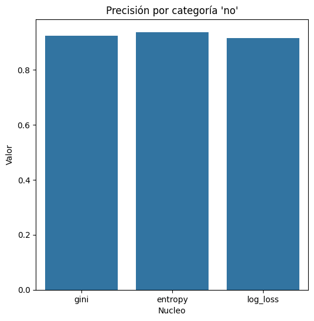

```python
lista_indices_rfc = [indices_gini, indices_entropy, indices_log_loss]
metricas_barchart(nombre_nucleos_rfc,
                  lista_indices_rfc)
```

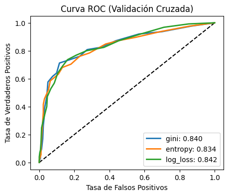

```python
probs_rfc = {
    'gini': prob_gini,
    'entropy': prob_entropy,
    'log_loss': prob_log_loss
}
imprimir_ROC_cv(y_real_rfc, probs_rfc)
```

##### Probabilidades de Corte

```python
imp_umbral_corte(modelo_log_loss, X_te, y_te, y_vec, nucleo="criterion") #, corte = np.arange(0.3, 0.4, 0.01))
```

```
==========================================
Probabilidad de Corte de criterion: log_loss
==========================================
  Corte        PG        PN        PP
0  0.00  0.357143  0.100000  1.000000
1  0.10  0.666667  0.533333  1.000000
2  0.20  0.833333  0.800000  0.916667
3  0.30  0.880952  0.866667  0.916667
4  0.40  0.904762  0.933333  0.833333
5  0.50  0.833333  0.933333  0.583333
6  0.60  0.785714  0.966667  0.333333
7  0.70  0.714286  0.966667  0.083333
8  0.80  0.738095  1.000000  0.083333
9  0.90  0.714286  1.000000  0.000000
```

```python
# imp_umbral_corte(modelo_log_loss, X_te, y_te, y_vec, nucleo="criterion", corte = np.arange(0.1, 0.3, 0.01))
```

#### Resultados

```python
df_rfc_indices = dataframe_desde_indices(
    indices=[indices_gini, indices_entropy, indices_log_loss],
    nucleo=['rfc_gini', 'rfc_entropy', 'rfc_log_loss']
)

df_rfc_indices
```

|  | Modelo | Precisión Global | Error Global | Precisión Positiva (PP) | Precisión Negativa (PN) |
| --- | --- | --- | --- | --- | --- |
| 0 | rfc_gini | 0.834499 | 0.165501 | 0.616 | 0.924342 |
| 1 | rfc_entropy | 0.834499 | 0.165501 | 0.584 | 0.937500 |
| 2 | rfc_log_loss | 0.813520 | 0.186480 | 0.568 | 0.914474 |

#### **AdaBoostClassifier**

```python
y_vec  = np.asarray(y).ravel()
clases = np.unique(y_vec)

kfold = StratifiedKFold(n_splits=10, shuffle=True)  # sin random_state

mc_md1_abc     = np.zeros((len(clases), len(clases)), dtype=int)
mc_md2_abc  = np.zeros_like(mc_md1_abc)
mc_md3_abc = np.zeros_like(mc_md1_abc)

y_real_abc = []
prob_md1_abc = []
prob_md2_abc = []
prob_md3_abc = []
for train_idx, test_idx in kfold.split(X, y_vec):
  X_tr, X_te = X.iloc[train_idx], X.iloc[test_idx]
  y_tr, y_te = y_vec[train_idx],  y_vec[test_idx]

  y_real_abc.extend(y_te)

  # max_depth=1
  modelo_md1_abc = Pipeline(steps=[
    ('preprocesador', preprocesamiento),
    ('clasificador', AdaBoostClassifier(n_estimators=21, learning_rate = 0.1, estimator = DecisionTreeClassifier(max_depth=1)))
  ])
  modelo_md1_abc.fit(X_tr, y_tr)
  mc_md1_abc += confusion_matrix(y_te, modelo_md1_abc.predict(X_te), labels=clases)
  prob_md1_abc.extend(modelo_md1_abc.predict_proba(X_te)[:, 1])

  # max_depth=2
  modelo_md2_abc = Pipeline(steps=[
    ('preprocesador', preprocesamiento),
    ('clasificador', AdaBoostClassifier(n_estimators=21, learning_rate = 0.1, estimator = DecisionTreeClassifier(max_depth=2)))
  ])
  modelo_md2_abc.fit(X_tr, y_tr)
  mc_md2_abc += confusion_matrix(y_te, modelo_md2_abc.predict(X_te), labels=clases)
  prob_md2_abc.extend(modelo_md2_abc.predict_proba(X_te)[:, 1])

  # max_depth=3
  modelo_md3_abc = Pipeline(steps=[
    ('preprocesador', preprocesamiento),
    ('clasificador', AdaBoostClassifier(n_estimators=21, learning_rate = 0.1, estimator = DecisionTreeClassifier(max_depth=3)))
  ])
  modelo_md3_abc.fit(X_tr, y_tr)
  mc_md3_abc += confusion_matrix(y_te, modelo_md3_abc.predict(X_te), labels=clases)
  prob_md3_abc.extend(modelo_md3_abc.predict_proba(X_te)[:, 1])



lista_mc_modelo_abc = [mc_md1_abc, mc_md2_abc, mc_md3_abc]
lista_param_abc = [modelo_md1_abc, modelo_md2_abc, modelo_md3_abc]
```

##### Evaluación AdaBoostClassifier

```python
indices_abc = metricas_manuales(labels,
                                lista_mc_modelo_abc,
                                lista_param_abc,
                                nucleo='estimator')
```

```
====================================================
Modelo: AdaBoostClassifier, estimator: DecisionTreeClassifier(max_depth=1)
====================================================
Matriz de Confusión:
[[288  16]
 [103  22]]

Precisión Global:
0.7226107226107226

Error Global:
0.27738927738927743

Precisión por categoría:
         no    yes
0  0.947368  0.176

====================================================
Modelo: AdaBoostClassifier, estimator: DecisionTreeClassifier(max_depth=2)
====================================================
Matriz de Confusión:
[[284  20]
 [ 62  63]]

Precisión Global:
0.8088578088578089

Error Global:
0.1911421911421911

Precisión por categoría:
         no    yes
0  0.934211  0.504

====================================================
Modelo: AdaBoostClassifier, estimator: DecisionTreeClassifier(max_depth=3)
====================================================
Matriz de Confusión:
[[277  27]
 [ 44  81]]

Precisión Global:
0.8344988344988346

Error Global:
0.16550116550116545

Precisión por categoría:
         no    yes
0  0.911184  0.648
```

```python
indices_md1 = indices_abc['DecisionTreeClassifier(max_depth=1)']
indices_md2 = indices_abc['DecisionTreeClassifier(max_depth=2)']
indices_md3 = indices_abc['DecisionTreeClassifier(max_depth=3)']

nombre_nucleos_abc = ["DecisionTreeClassifier(max_depth=1)", "DecisionTreeClassifier(max_depth=2)", "DecisionTreeClassifier(max_depth=3)"]
```

##### Gráficos

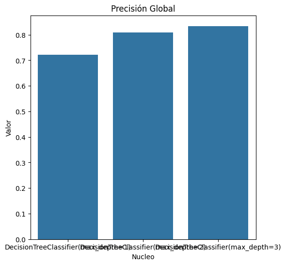

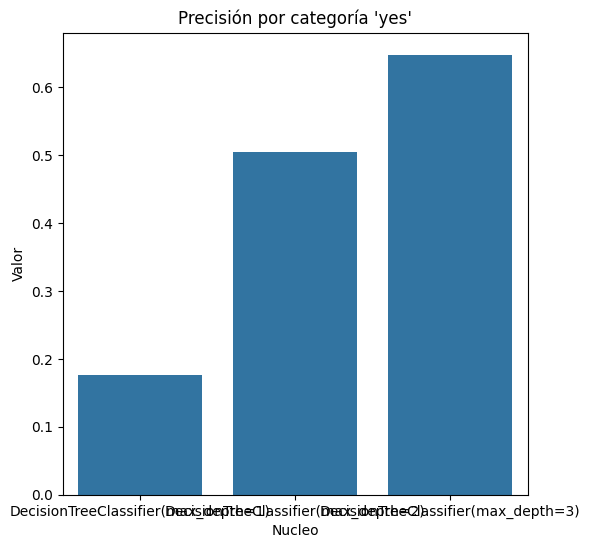

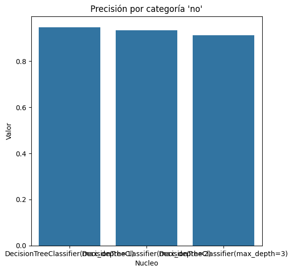

```python
lista_indices_abc = [indices_md1, indices_md2, indices_md3]
metricas_barchart(nombre_nucleos_abc,
                  lista_indices_abc)
```

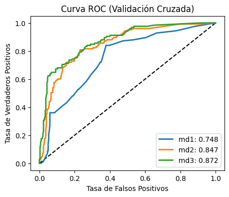

```python
probs_abc = {
    'md1': prob_md1_abc,
    'md2': prob_md2_abc,
    'md3': prob_md3_abc
}
imprimir_ROC_cv(y_real_abc, probs_abc)
```

##### Probabilidades de Corte

```python
imp_umbral_corte(modelo_md3_abc, X_te, y_te, y_vec, nucleo="estimator") #, corte = np.arange(0.3, 0.4, 0.01))
```

```
==========================================
Probabilidad de Corte de estimator: DecisionTreeClassifier(max_depth=3)
==========================================
  Corte        PG        PN        PP
0  0.00  0.285714  0.000000  1.000000
1  0.10  0.285714  0.000000  1.000000
2  0.20  0.714286  0.600000  1.000000
3  0.30  0.809524  0.766667  0.916667
4  0.40  0.857143  0.933333  0.666667
5  0.50  0.904762  1.000000  0.666667
6  0.60  0.904762  1.000000  0.666667
7  0.70  0.785714  1.000000  0.250000
8  0.80  0.738095  1.000000  0.083333
9  0.90  0.714286  1.000000  0.000000
```

```python
imp_umbral_corte(modelo_md3_abc, X_te, y_te, y_vec, nucleo="estimator", corte = np.arange(0.3, 0.4, 0.01))
```

```
==========================================
Probabilidad de Corte de estimator: DecisionTreeClassifier(max_depth=3)
==========================================
   Corte        PG        PN        PP
0   0.30  0.809524  0.766667  0.916667
1   0.31  0.809524  0.766667  0.916667
2   0.32  0.809524  0.766667  0.916667
3   0.33  0.785714  0.766667  0.833333
4   0.34  0.785714  0.766667  0.833333
5   0.35  0.761905  0.766667  0.750000
6   0.36  0.785714  0.800000  0.750000
7   0.37  0.809524  0.833333  0.750000
8   0.38  0.809524  0.833333  0.750000
9   0.39  0.857143  0.933333  0.666667
10  0.40  0.857143  0.933333  0.666667
```

#### Resultados

```python
df_abc_indices = dataframe_desde_indices(
    indices=[indices_md1, indices_md2, indices_md3],
    nucleo=['abc_max_depth1', 'abc_max_depth2', 'abc_max_depth3']
)

df_abc_indices
```

|  | Modelo | Precisión Global | Error Global | Precisión Positiva (PP) | Precisión Negativa (PN) |
| --- | --- | --- | --- | --- | --- |
| 0 | abc_max_depth3 | 0.834499 | 0.165501 | 0.648 | 0.911184 |
| 1 | abc_max_depth2 | 0.808858 | 0.191142 | 0.504 | 0.934211 |
| 2 | abc_max_depth1 | 0.722611 | 0.277389 | 0.176 | 0.947368 |

```python
y_vec  = np.asarray(y).ravel()
clases = np.unique(y_vec)

kfold = StratifiedKFold(n_splits=10, shuffle=True)  # sin random_state

mc_sqrt_xg     = np.zeros((len(clases), len(clases)), dtype=int)
mc_log2_xg  = np.zeros_like(mc_sqrt_xg)

y_real_xg = []
prob_sqrt_xg = []
prob_log2_xg = []
for train_idx, test_idx in kfold.split(X, y_vec):
  X_tr, X_te = X.iloc[train_idx], X.iloc[test_idx]
  y_tr, y_te = y_vec[train_idx],  y_vec[test_idx]

  y_real_xg.extend(y_te)

  # sqrt
  modelo_sqrt_xg = Pipeline(steps=[
    ('preprocesador', preprocesamiento),
    ('clasificador', GradientBoostingClassifier(n_estimators = 21, learning_rate = 1.0, max_features = 'sqrt', max_depth = 15))
  ])
  modelo_sqrt_xg.fit(X_tr, y_tr)
  mc_sqrt_xg += confusion_matrix(y_te, modelo_sqrt_xg.predict(X_te), labels=clases)
  prob_sqrt_xg.extend(modelo_sqrt_xg.predict_proba(X_te)[:, 1])

  # log2
  modelo_log2_xg = Pipeline(steps=[
    ('preprocesador', preprocesamiento),
    ('clasificador', GradientBoostingClassifier(n_estimators = 21, learning_rate = 1.0, max_features = 'log2', max_depth = 15))
  ])
  modelo_log2_xg.fit(X_tr, y_tr)
  mc_log2_xg += confusion_matrix(y_te, modelo_log2_xg.predict(X_te), labels=clases)
  prob_log2_xg.extend(modelo_log2_xg.predict_proba(X_te)[:, 1])

lista_mc_modelo_xg = [mc_sqrt_xg, mc_log2_xg]
lista_param_xg = [modelo_sqrt_xg, modelo_log2_xg]
```

```python
indices_xg = metricas_manuales(labels,
                                lista_mc_modelo_xg,
                                lista_param_xg,
                                nucleo='max_features')
```

```
====================================================
Modelo: GradientBoostingClassifier, max_features: sqrt
====================================================
Matriz de Confusión:
[[276  28]
 [ 55  70]]

Precisión Global:
0.8065268065268065

Error Global:
0.19347319347319347

Precisión por categoría:
         no   yes
0  0.907895  0.56

====================================================
Modelo: GradientBoostingClassifier, max_features: log2
====================================================
Matriz de Confusión:
[[275  29]
 [ 54  71]]

Precisión Global:
0.8065268065268065

Error Global:
0.19347319347319347

Precisión por categoría:
         no    yes
0  0.904605  0.568
```

```python
indices_sqrt = indices_xg['sqrt']
indices_log2 = indices_xg['log2']

nombre_nucleos_xg = ["sqrt", "log2"]
```

##### Gráficos

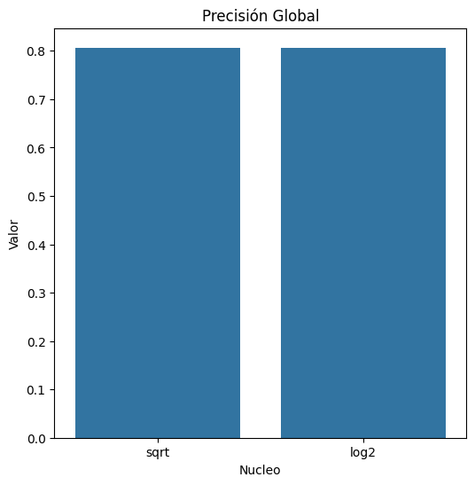

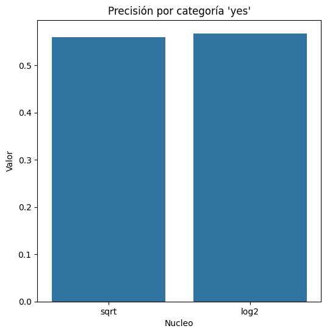

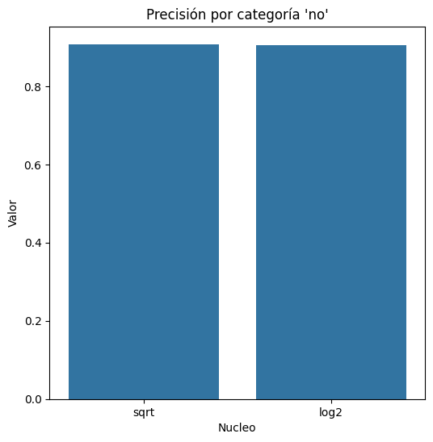

```python
lista_indices_xg = [indices_sqrt, indices_log2]
metricas_barchart(nombre_nucleos_xg,
                  lista_indices_xg)
```

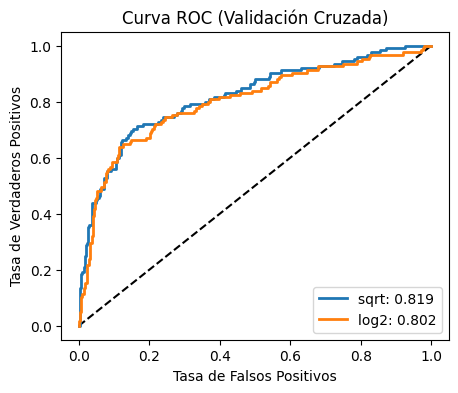

```python
probs_xg = {
    'sqrt': prob_sqrt_xg,
    'log2': prob_log2_xg
}
imprimir_ROC_cv(y_real_xg, probs_xg)
```

##### Probabilidades de Corte

```python
imp_umbral_corte(modelo_sqrt_xg, X_te, y_te, y_vec, nucleo="max_features") #, corte = np.arange(0.3, 0.4, 0.01))
imp_umbral_corte(modelo_log2_xg, X_te, y_te, y_vec, nucleo="max_features") #, corte = np.arange(0.3, 0.4, 0.01))
```

```
==========================================
Probabilidad de Corte de max_features: sqrt
==========================================
  Corte        PG        PN        PP
0  0.00  0.285714  0.000000  1.000000
1  0.10  0.738095  0.833333  0.500000
2  0.20  0.738095  0.833333  0.500000
3  0.30  0.738095  0.833333  0.500000
4  0.40  0.761905  0.866667  0.500000
5  0.50  0.761905  0.866667  0.500000
6  0.60  0.761905  0.866667  0.500000
7  0.70  0.761905  0.900000  0.416667
8  0.80  0.714286  0.900000  0.250000
9  0.90  0.714286  0.900000  0.250000
==========================================
Probabilidad de Corte de max_features: log2
==========================================
  Corte        PG        PN        PP
0  0.00  0.285714  0.000000  1.000000
1  0.10  0.761905  0.833333  0.583333
2  0.20  0.738095  0.866667  0.416667
3  0.30  0.714286  0.866667  0.333333
4  0.40  0.714286  0.866667  0.333333
5  0.50  0.714286  0.866667  0.333333
6  0.60  0.738095  0.900000  0.333333
7  0.70  0.738095  0.900000  0.333333
8  0.80  0.714286  0.900000  0.250000
9  0.90  0.714286  0.900000  0.250000
```

```python
# imp_umbral_corte(modelo_sqrt_xg, X_te, y_te, y_vec, nucleo="max_features", corte = np.arange(0.4, 0.5, 0.01))
```

#### Resultados

```python
df_xg_indices = dataframe_desde_indices(
    indices=[indices_sqrt, indices_log2],
    nucleo=['xg_sqrt', 'xg_log2']
)

df_xg_indices
```

|  | Modelo | Precisión Global | Error Global | Precisión Positiva (PP) | Precisión Negativa (PN) |
| --- | --- | --- | --- | --- | --- |
| 0 | xg_sqrt | 0.806527 | 0.193473 | 0.560 | 0.907895 |
| 1 | xg_log2 | 0.806527 | 0.193473 | 0.568 | 0.904605 |

- Se utilizara el max_features = sqrt con el corte de probabilidad 0.20

#### **Bayes Classifier (GaussianNB)**

```python
y_vec  = np.asarray(y).ravel()
clases = np.unique(y_vec)

kfold = StratifiedKFold(n_splits=10, shuffle=True)  # sin random_state

mc_bayes     = np.zeros((len(clases), len(clases)), dtype=int)

y_real_bayes = []
prob_bayes = []
for train_idx, test_idx in kfold.split(X, y_vec):
  X_tr, X_te = X.iloc[train_idx], X.iloc[test_idx]
  y_tr, y_te = y_vec[train_idx],  y_vec[test_idx]

  y_real_bayes.extend(y_te)

  # bayes
  modelo_bayes = Pipeline(steps=[
    ('preprocesador', preprocesamiento),
    ('clasificador', GaussianNB())
  ])
  modelo_bayes.fit(X_tr, y_tr)
  mc_bayes += confusion_matrix(y_te, modelo_bayes.predict(X_te), labels=clases)
  prob_bayes.extend(modelo_bayes.predict_proba(X_te)[:, 1])

lista_mc_modelo_bayes = [mc_bayes]
lista_param_bayes = [modelo_bayes]
```

##### Evaluación Bayes

```python
indices_bayes = metricas_manuales(labels,
                                  lista_mc_modelo_bayes,
                                  lista_param_bayes)
                                  # nucleo=None)

nombre_nucleos_bayes = ["bayes"]
```

```
====================================================
Modelo: GaussianNB()
====================================================
Matriz de Confusión:
[[ 40 264]
 [ 23 102]]

Precisión Global:
0.331002331002331

Error Global:
0.668997668997669

Precisión por categoría:
         no    yes
0  0.131579  0.816
```

##### Gráficos

```python
indices_bayes
```

```
{'GaussianNB()': {'Matriz de Confusión': array([[ 40, 264],
         [ 23, 102]]),
  'Precisión Global': np.float64(0.331002331002331),
  'Error Global': np.float64(0.668997668997669),
  'Precisión por categoría':          no    yes
  0  0.131579  0.816}}
```

```python
df_bayes_indices = pd.DataFrame({
    'Modelo': nombre_nucleos_bayes,
    'Precisión Global': indices_bayes["GaussianNB()"]['Precisión Global'],
    'Error Global': indices_bayes["GaussianNB()"]['Error Global'],
    'Precisión Positiva (PP)': indices_bayes["GaussianNB()"]['Precisión por categoría']['yes'].values[0],
    'Precisión Negativa (PN)': indices_bayes["GaussianNB()"]['Precisión por categoría']['no'].values[0]
})
df_bayes_indices
```

|  | Modelo | Precisión Global | Error Global | Precisión Positiva (PP) | Precisión Negativa (PN) |
| --- | --- | --- | --- | --- | --- |
| 0 | bayes | 0.331002 | 0.668998 | 0.816 | 0.131579 |

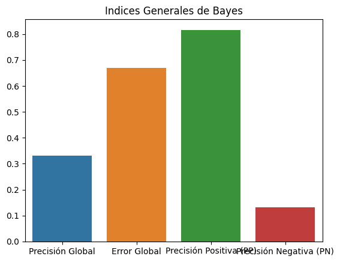

```python
# df_bayes_indices.plot.bar()
# plt.title('Gráfico de Barras con Pandas')
# plt.show()

sns.barplot(data = df_bayes_indices)
plt.title('Indices Generales de Bayes')
plt.show()
```

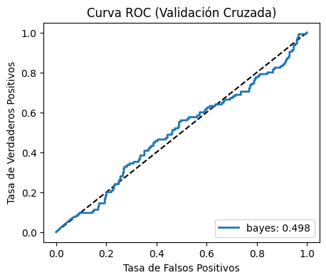

```python
probs_bayes = {
    'bayes': prob_bayes
}
imprimir_ROC_cv(y_real_bayes, probs_bayes)
```

##### Probabilidades de Corte

```python
imp_umbral_corte(modelo_bayes,
                 X_te,
                 y_te,
                 y_vec
                 )#, nucleo="max_features") #, corte = np.arange(0.3, 0.4, 0.01))
```

```
==========================================
Probabilidad de Corte de : GaussianNB()
==========================================
  Corte        PG        PN        PP
0  0.00  0.285714  0.000000  1.000000
1  0.10  0.309524  0.033333  1.000000
2  0.20  0.309524  0.033333  1.000000
3  0.30  0.285714  0.033333  0.916667
4  0.40  0.261905  0.033333  0.833333
5  0.50  0.261905  0.033333  0.833333
6  0.60  0.261905  0.066667  0.750000
7  0.70  0.309524  0.133333  0.750000
8  0.80  0.404762  0.400000  0.416667
9  0.90  0.595238  0.733333  0.250000
```

#### Resultados

```python
df_bayes_indices
```

|  | Modelo | Precisión Global | Error Global | Precisión Positiva (PP) | Precisión Negativa (PN) |
| --- | --- | --- | --- | --- | --- |
| 0 | bayes | 0.331002 | 0.668998 | 0.816 | 0.131579 |

#### **LinearDiscriminantAnalysis**

```python
y_vec  = np.asarray(y).ravel()
clases = np.unique(y_vec)

kfold = StratifiedKFold(n_splits=10, shuffle=True)  # sin random_state

mc_svd_lda     = np.zeros((len(clases), len(clases)), dtype=int)
mc_lsqr_lda  = np.zeros_like(mc_svd_lda)
mc_eigen_lda = np.zeros_like(mc_svd_lda)

y_real_lda = []
prob_svd_lda = []
prob_lsqr_lda = []
prob_eigen_lda = []
for train_idx, test_idx in kfold.split(X, y_vec):
  X_tr, X_te = X.iloc[train_idx], X.iloc[test_idx]
  y_tr, y_te = y_vec[train_idx],  y_vec[test_idx]

  y_real_lda.extend(y_te)

  # svd_lda
  modelo_svd_lda = Pipeline(steps=[
    ('preprocesador', preprocesamiento),
    ('clasificador', LinearDiscriminantAnalysis(solver = 'svd', shrinkage = None))
  ])
  modelo_svd_lda.fit(X_tr, y_tr)
  mc_svd_lda += confusion_matrix(y_te, modelo_svd_lda.predict(X_te), labels=clases)
  prob_svd_lda.extend(modelo_svd_lda.predict_proba(X_te)[:, 1])

  # lsqr_lda
  modelo_lsqr_lda = Pipeline(steps=[
    ('preprocesador', preprocesamiento),
    ('clasificador', LinearDiscriminantAnalysis(solver = 'lsqr', shrinkage = 'auto'))
  ])
  modelo_lsqr_lda.fit(X_tr, y_tr)
  mc_lsqr_lda += confusion_matrix(y_te, modelo_lsqr_lda.predict(X_te), labels=clases)
  prob_lsqr_lda.extend(modelo_lsqr_lda.predict_proba(X_te)[:, 1])

  # eigen_lda
  modelo_eigen_lda = Pipeline(steps=[
    ('preprocesador', preprocesamiento),
    ('clasificador', LinearDiscriminantAnalysis(solver = 'eigen', shrinkage = 'auto'))
  ])
  modelo_eigen_lda.fit(X_tr, y_tr)
  mc_eigen_lda += confusion_matrix(y_te, modelo_eigen_lda.predict(X_te), labels=clases)
  prob_eigen_lda.extend(modelo_eigen_lda.predict_proba(X_te)[:, 1])
# mc_svd_lda
# mc_lsqr_lda
# mc_eigen_lda

lista_mc_modelo_lda = [mc_svd_lda, mc_lsqr_lda, mc_eigen_lda]
lista_param_lda = [modelo_svd_lda, modelo_lsqr_lda, modelo_eigen_lda]
```

##### Evaluación LDA

```python
indices_lda = metricas_manuales(labels,
                                lista_mc_modelo_lda,
                                lista_param_lda,
                                nucleo='solver')

indices_svd = indices_lda['svd']
indices_lsqr = indices_lda['lsqr']
indices_eigen = indices_lda['eigen']

nombre_nucleos_lda = ["svd", "lsqr", "eigen"]
```

```
====================================================
Modelo: LinearDiscriminantAnalysis, solver: svd
====================================================
Matriz de Confusión:
[[281  23]
 [108  17]]

Precisión Global:
0.6946386946386947

Error Global:
0.30536130536130535

Precisión por categoría:
         no    yes
0  0.924342  0.136

====================================================
Modelo: LinearDiscriminantAnalysis, solver: lsqr
====================================================
Matriz de Confusión:
[[287  17]
 [112  13]]

Precisión Global:
0.6993006993006993

Error Global:
0.30069930069930073

Precisión por categoría:
         no    yes
0  0.944079  0.104

====================================================
Modelo: LinearDiscriminantAnalysis, solver: eigen
====================================================
Matriz de Confusión:
[[287  17]
 [112  13]]

Precisión Global:
0.6993006993006993

Error Global:
0.30069930069930073

Precisión por categoría:
         no    yes
0  0.944079  0.104
```

##### Gráficos

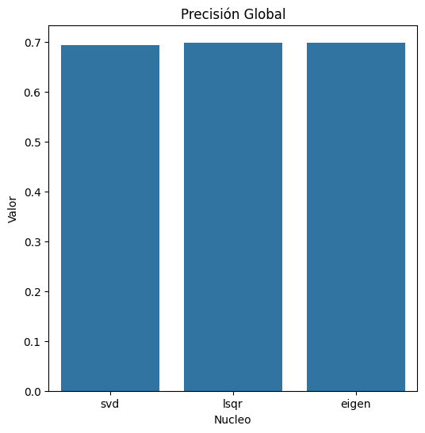

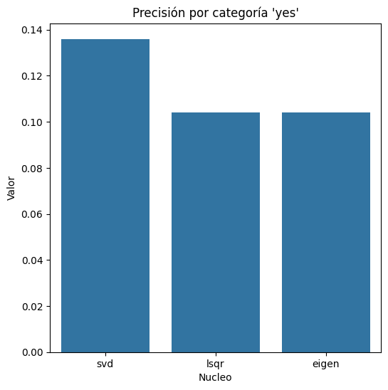

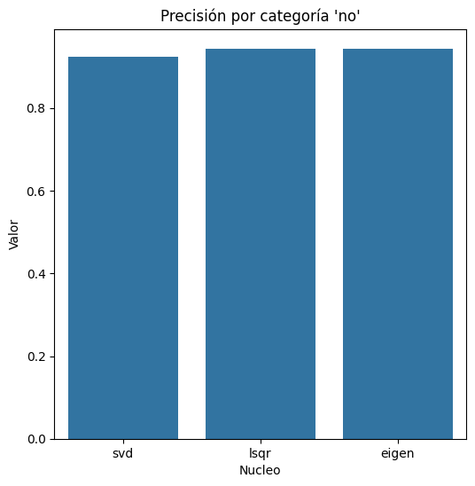

```python
lista_indices_lda = [indices_svd, indices_lsqr, indices_eigen]
metricas_barchart(nombre_nucleos_lda,
                  lista_indices_lda)
```

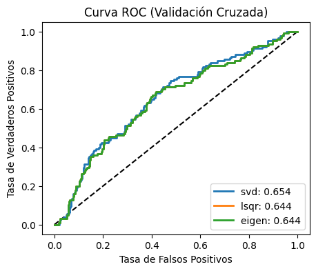

```python
probs_lda = {
    'svd': prob_svd_lda,
    'lsqr': prob_lsqr_lda,
    'eigen': prob_eigen_lda
}
imprimir_ROC_cv(y_real_lda, probs_lda)
```

##### Probabilidades de Corte

```python
imp_umbral_corte(modelo_svd_lda, X_te, y_te, y_vec, nucleo="solver") #, corte = np.arange(0.3, 0.4, 0.01))
```

```
==========================================
Probabilidad de Corte de solver: svd
==========================================
  Corte        PG        PN        PP
0  0.00  0.285714  0.000000  1.000000
1  0.10  0.309524  0.033333  1.000000
2  0.20  0.500000  0.400000  0.750000
3  0.30  0.500000  0.600000  0.250000
4  0.40  0.619048  0.833333  0.083333
5  0.50  0.690476  0.966667  0.000000
6  0.60  0.714286  1.000000  0.000000
7  0.70  0.714286  1.000000  0.000000
8  0.80  0.714286  1.000000  0.000000
9  0.90  0.714286  1.000000  0.000000
```

```python
imp_umbral_corte(modelo_svd_lda, X_te, y_te, y_vec, nucleo="solver", corte = np.arange(0.2, 0.4, 0.01))
```

```
==========================================
Probabilidad de Corte de solver: svd
==========================================
   Corte        PG        PN        PP
0   0.20  0.500000  0.400000  0.750000
1   0.21  0.523810  0.433333  0.750000
2   0.22  0.523810  0.466667  0.666667
3   0.23  0.547619  0.500000  0.666667
4   0.24  0.571429  0.533333  0.666667
5   0.25  0.571429  0.533333  0.666667
6   0.26  0.500000  0.533333  0.416667
7   0.27  0.500000  0.566667  0.333333
8   0.28  0.500000  0.566667  0.333333
9   0.29  0.523810  0.600000  0.333333
10  0.30  0.500000  0.600000  0.250000
11  0.31  0.500000  0.600000  0.250000
12  0.32  0.523810  0.633333  0.250000
13  0.33  0.547619  0.666667  0.250000
14  0.34  0.571429  0.700000  0.250000
15  0.35  0.571429  0.700000  0.250000
16  0.36  0.619048  0.766667  0.250000
17  0.37  0.619048  0.766667  0.250000
18  0.38  0.642857  0.800000  0.250000
19  0.39  0.595238  0.800000  0.083333
```

#### Resultados

```python
df_lda_indices = dataframe_desde_indices(
    indices=[indices_svd, indices_lsqr, indices_eigen],
    nucleo=['lda_svd', 'lda_lsqr', 'lda_eigen']
)

df_lda_indices
```

|  | Modelo | Precisión Global | Error Global | Precisión Positiva (PP) | Precisión Negativa (PN) |
| --- | --- | --- | --- | --- | --- |
| 0 | lda_lsqr | 0.699301 | 0.300699 | 0.104 | 0.944079 |
| 1 | lda_eigen | 0.699301 | 0.300699 | 0.104 | 0.944079 |
| 2 | lda_svd | 0.694639 | 0.305361 | 0.136 | 0.924342 |

#### **QuadraticDiscriminantAnalysis**

```python
y_vec  = np.asarray(y).ravel()
clases = np.unique(y_vec)

kfold = StratifiedKFold(n_splits=10, shuffle=True)  # sin random_state

mc_rp1_qda     = np.zeros((len(clases), len(clases)), dtype=int)
mc_rp3_qda  = np.zeros_like(mc_rp1_qda)
mc_rp5_qda = np.zeros_like(mc_rp1_qda)

y_real_qda = []
prob_rp1_qda = []
prob_rp3_qda = []
prob_rp5_qda = []
for train_idx, test_idx in kfold.split(X, y_vec):
  X_tr, X_te = X.iloc[train_idx], X.iloc[test_idx]
  y_tr, y_te = y_vec[train_idx],  y_vec[test_idx]

  y_real_qda.extend(y_te)

  # rp1_qda
  modelo_rp1_qda = Pipeline(steps=[
    ('preprocesador', preprocesamiento),
    ('clasificador', QuadraticDiscriminantAnalysis(reg_param = 0.1))
  ])
  modelo_rp1_qda.fit(X_tr, y_tr)
  mc_rp1_qda += confusion_matrix(y_te, modelo_rp1_qda.predict(X_te), labels=clases)
  prob_rp1_qda.extend(modelo_rp1_qda.predict_proba(X_te)[:, 1])

  # rp3_qda
  modelo_rp3_qda = Pipeline(steps=[
    ('preprocesador', preprocesamiento),
    ('clasificador', QuadraticDiscriminantAnalysis(reg_param = 0.3))
  ])
  modelo_rp3_qda.fit(X_tr, y_tr)
  mc_rp3_qda += confusion_matrix(y_te, modelo_rp3_qda.predict(X_te), labels=clases)
  prob_rp3_qda.extend(modelo_rp3_qda.predict_proba(X_te)[:, 1])

  # rp5_qda
  modelo_rp5_qda = Pipeline(steps=[
    ('preprocesador', preprocesamiento),
    ('clasificador', QuadraticDiscriminantAnalysis(reg_param = 0.5))

  ])
  modelo_rp5_qda.fit(X_tr, y_tr)
  mc_rp5_qda += confusion_matrix(y_te, modelo_rp5_qda.predict(X_te), labels=clases)
  prob_rp5_qda.extend(modelo_rp5_qda.predict_proba(X_te)[:, 1])


lista_mc_modelo_qda = [mc_rp1_qda, mc_rp3_qda, mc_rp5_qda]
lista_param_qda = [modelo_rp1_qda, modelo_rp3_qda, modelo_rp5_qda]
```

##### Evaluación QDA

```python
indices_qda = metricas_manuales(labels,
                                lista_mc_modelo_qda,
                                lista_param_qda,
                                nucleo='reg_param')

indices_rp1 = indices_qda['0.1']
indices_rp3 = indices_qda['0.3']
indices_rp5 = indices_qda['0.5']

nombre_nucleos_qda = ["rp1", "rp3", "rp5"]
```

```
====================================================
Modelo: QuadraticDiscriminantAnalysis, reg_param: 0.1
====================================================
Matriz de Confusión:
[[254  50]
 [ 76  49]]

Precisión Global:
0.7062937062937062

Error Global:
0.29370629370629375

Precisión por categoría:
         no    yes
0  0.835526  0.392

====================================================
Modelo: QuadraticDiscriminantAnalysis, reg_param: 0.3
====================================================
Matriz de Confusión:
[[281  23]
 [ 88  37]]

Precisión Global:
0.7412587412587412

Error Global:
0.25874125874125875

Precisión por categoría:
         no    yes
0  0.924342  0.296

====================================================
Modelo: QuadraticDiscriminantAnalysis, reg_param: 0.5
====================================================
Matriz de Confusión:
[[288  16]
 [ 94  31]]

Precisión Global:
0.7435897435897436

Error Global:
0.2564102564102564

Precisión por categoría:
         no    yes
0  0.947368  0.248
```

##### Gráficos

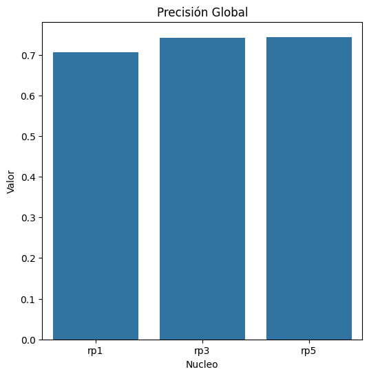

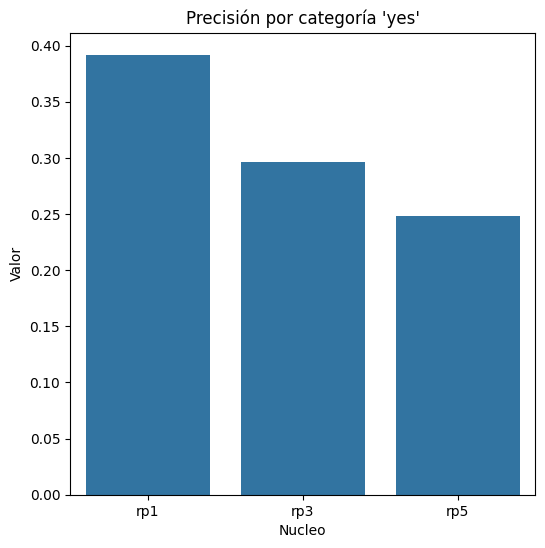

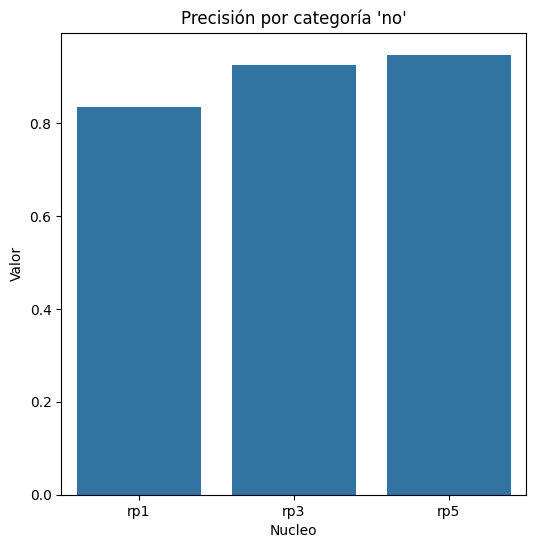

```python
lista_indices_qda = [indices_rp1, indices_rp3, indices_rp5]
metricas_barchart(nombre_nucleos_qda,
                  lista_indices_qda)
```

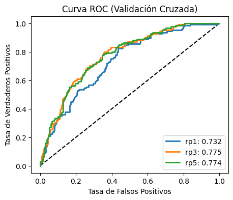

```python
probs_dqa = {
    'rp1': prob_rp1_qda,
    'rp3': prob_rp3_qda,
    'rp5': prob_rp5_qda
}
imprimir_ROC_cv(y_real_qda, probs_dqa)
```

##### Probabilidades de Corte

```python
imp_umbral_corte(modelo_rp1_qda, X_te, y_te, y_vec, nucleo="reg_param") #, corte = np.arange(0.3, 0.4, 0.01))
imp_umbral_corte(modelo_rp5_qda, X_te, y_te, y_vec, nucleo="reg_param") #, corte = np.arange(0.3, 0.4, 0.01))
```

```
==========================================
Probabilidad de Corte de reg_param: 0.1
==========================================
  Corte        PG        PN        PP
0  0.00  0.285714  0.000000  1.000000
1  0.10  0.595238  0.433333  1.000000
2  0.20  0.642857  0.500000  1.000000
3  0.30  0.714286  0.600000  1.000000
4  0.40  0.761905  0.700000  0.916667
5  0.50  0.761905  0.800000  0.666667
6  0.60  0.833333  0.966667  0.500000
7  0.70  0.785714  1.000000  0.250000
8  0.80  0.785714  1.000000  0.250000
9  0.90  0.714286  1.000000  0.000000
==========================================
Probabilidad de Corte de reg_param: 0.5
==========================================
  Corte        PG        PN        PP
0  0.00  0.285714  0.000000  1.000000
1  0.10  0.404762  0.166667  1.000000
2  0.20  0.595238  0.433333  1.000000
3  0.30  0.690476  0.600000  0.916667
4  0.40  0.761905  0.800000  0.666667
5  0.50  0.785714  0.900000  0.500000
6  0.60  0.714286  0.933333  0.166667
7  0.70  0.738095  1.000000  0.083333
8  0.80  0.714286  1.000000  0.000000
9  0.90  0.714286  1.000000  0.000000
```

```python
imp_umbral_corte(modelo_rp1_qda, X_te, y_te, y_vec, nucleo="reg_param", corte = np.arange(0.4, 0.5, 0.01))
```

```
==========================================
Probabilidad de Corte de reg_param: 0.1
==========================================
  Corte        PG        PN        PP
0  0.40  0.761905  0.700000  0.916667
1  0.41  0.785714  0.733333  0.916667
2  0.42  0.809524  0.766667  0.916667
3  0.43  0.809524  0.766667  0.916667
4  0.44  0.809524  0.766667  0.916667
5  0.45  0.833333  0.800000  0.916667
6  0.46  0.833333  0.800000  0.916667
7  0.47  0.809524  0.800000  0.833333
8  0.48  0.809524  0.800000  0.833333
9  0.49  0.785714  0.800000  0.750000
```

#### Resultados

```python
df_qda_indices = dataframe_desde_indices(
    indices=[indices_rp1, indices_rp3, indices_rp5],
    nucleo=['qda_rp1', 'qda_rp3', 'qda_rp5']
)

df_qda_indices
```

|  | Modelo | Precisión Global | Error Global | Precisión Positiva (PP) | Precisión Negativa (PN) |
| --- | --- | --- | --- | --- | --- |
| 0 | qda_rp5 | 0.743590 | 0.256410 | 0.248 | 0.947368 |
| 1 | qda_rp3 | 0.741259 | 0.258741 | 0.296 | 0.924342 |
| 2 | qda_rp1 | 0.706294 | 0.293706 | 0.392 | 0.835526 |

## Parte 2

- b) Construya un DataFrame que compare todos los modelos generados. Para esto en cada una de las filas debe aparecer el nombre del modelo predictivo y en las columnas deben aparecer los índices Precisión Global, Error Global, Precisión Positiva (PP) y Precisión Negativa (PN). Cuál de los modelos es mejor para estos datos?

↑ Volver al Menú

```python
y_vec  = np.asarray(y).ravel()
clases = np.unique(y_vec)

kfold = StratifiedKFold(n_splits=10, shuffle=True)  # sin random_state

mc_knn             = np.zeros((len(clases), len(clases)), dtype=int)
mc_arbol           = np.zeros_like(mc_knn)
mc_bosques         = np.zeros_like(mc_knn)
mc_potenciacion    = np.zeros_like(mc_knn)
mc_xg_potenciacion = np.zeros_like(mc_knn)
mc_svm             = np.zeros_like(mc_knn)
mc_bayes           = np.zeros_like(mc_knn)
mc_dis_lineal      = np.zeros_like(mc_knn)
mc_dis_cuadratico  = np.zeros_like(mc_knn)

for train_idx, test_idx in kfold.split(X, y_vec):
  X_tr, X_te = X.iloc[train_idx], X.iloc[test_idx]
  y_tr, y_te = y_vec[train_idx],  y_vec[test_idx]

  # ===== KNN =====
  modelo = Pipeline(steps=[
    ('preprocesador', preprocesamiento),
    ('clasificador', KNeighborsClassifier(n_neighbors=15, algorithm="ball_tree"))
  ])
  noimprimir = modelo.fit(X_tr, y_tr)

  probabilidades = modelo.predict_proba(X_te)
  probabilidad_yes = probabilidades[:, 1]
  c = 0.2
  prediccion = np.where(probabilidad_yes > c, "yes", "no")

  pred_fold  = modelo.predict(X_te)
  mc_knn     = mc_knn + confusion_matrix(y_te, prediccion, labels=clases)

  # ===== DecisionTreeClassifer =====
  modelo = Pipeline(steps=[
    ('preprocesador', preprocesamiento),
    ('clasificador', DecisionTreeClassifier(criterion='log_loss', max_depth=4, min_samples_split=2, min_samples_leaf=2))

  ])
  noimprimir = modelo.fit(X_tr, y_tr)
  probabilidades = modelo.predict_proba(X_te)
  probabilidad_yes = probabilidades[:, 1]
  c = 0.20
  prediccion = np.where(probabilidad_yes > c, "yes", "no")
  pred_fold  = modelo.predict(X_te)
  mc_arbol   = mc_arbol + confusion_matrix(y_te, prediccion, labels=clases)

  # ===== RandomForestClassifier =====
  modelo = Pipeline(steps=[
    ('preprocesador', preprocesamiento),
    ('clasificador', RandomForestClassifier(n_estimators=21, criterion="log_loss"))
  ])
  noimprimir = modelo.fit(X_tr, y_tr)
  probabilidades = modelo.predict_proba(X_te)
  probabilidad_yes = probabilidades[:, 1]
  c = 0.3
  prediccion = np.where(probabilidad_yes > c, "yes", "no")
  pred_fold  = modelo.predict(X_te)
  mc_bosques = mc_bosques + confusion_matrix(y_te, prediccion, labels=clases)

  # ===== AdaBoostClassifier | Potenciación (Boosting) =====
  modelo = Pipeline(steps=[
    ('preprocesador', preprocesamiento),
    ('clasificador', AdaBoostClassifier(n_estimators=21, learning_rate = 0.1, estimator = DecisionTreeClassifier(max_depth=3)))
  ])
  noimprimir = modelo.fit(X_tr, y_tr)
  probabilidades = modelo.predict_proba(X_te)
  probabilidad_yes = probabilidades[:, 1]
  c = 0.34
  prediccion = np.where(probabilidad_yes > c, "yes", "no")
  pred_fold  = modelo.predict(X_te)
  mc_potenciacion = mc_potenciacion + confusion_matrix(y_te, prediccion, labels=clases)

  # ===== Potenciación Extrema (Gradient Boosting) =====
  modelo = Pipeline(steps=[
    ('preprocesador', preprocesamiento),
    ('clasificador', GradientBoostingClassifier(n_estimators = 21, learning_rate = 1.0, max_features = 'sqrt', max_depth = 15))
  ])
  noimprimir = modelo.fit(X_tr, y_tr)
  probabilidades = modelo.predict_proba(X_te)
  probabilidad_yes = probabilidades[:, 1]
  c = 0.50 # por defecto
  prediccion = np.where(probabilidad_yes > c, "yes", "no")
  pred_fold  = modelo.predict(X_te)
  mc_xg_potenciacion = mc_xg_potenciacion + confusion_matrix(y_te, prediccion, labels=clases)

  # ===== Máquinas de Soporte Vectorial =====
  modelo = Pipeline(steps=[
    ('preprocesador', preprocesamiento),
    ('clasificador', SVC(kernel='poly', gamma='scale', probability=True))
  ])
  noimprimir = modelo.fit(X_tr, y_tr)
  probabilidades = modelo.predict_proba(X_te)
  probabilidad_yes = probabilidades[:, 1]
  c = 0.3
  prediccion = np.where(probabilidad_yes > c, "yes", "no")
  pred_fold  = modelo.predict(X_te)
  mc_svm = mc_svm + confusion_matrix(y_te, prediccion, labels=clases)

  # ===== Método Ingenuo de Bayes =====
  modelo = Pipeline(steps=[
    ('preprocesador', preprocesamiento),
    ('clasificador', GaussianNB())
  ])
  noimprimir = modelo.fit(X_tr, y_tr)
  pred_fold  = modelo.predict(X_te)
  mc_bayes   = mc_bayes + confusion_matrix(y_te, pred_fold, labels=clases)

  # ===== Análisis Discriminante Lineal =====
  modelo = Pipeline(steps=[
    ('preprocesador', preprocesamiento),
    ('clasificador', LinearDiscriminantAnalysis(solver='svd', shrinkage=None))
  ])
  noimprimir = modelo.fit(X_tr, y_tr)
  probabilidades = modelo.predict_proba(X_te)
  probabilidad_yes = probabilidades[:, 1]
  c = 0.50 # x defecto
  prediccion = np.where(probabilidad_yes > c, "yes", "no")
  pred_fold  = modelo.predict(X_te)
  mc_dis_lineal  = mc_dis_lineal + confusion_matrix(y_te, prediccion, labels=clases)

  # ===== Análisis Discriminante Cuadrático =====
  modelo = Pipeline(steps=[
    ('preprocesador', preprocesamiento),
    ('clasificador', QuadraticDiscriminantAnalysis(reg_param = 0.1))
  ])
  noimprimir = modelo.fit(X_tr, y_tr)
  probabilidades = modelo.predict_proba(X_te)
  probabilidad_yes = probabilidades[:, 1]
  c = 0.45
  prediccion = np.where(probabilidad_yes > c, "yes", "no")
  pred_fold  = modelo.predict(X_te)
  mc_dis_cuadratico = mc_dis_cuadratico + confusion_matrix(y_te, prediccion, labels=clases)

print(f"mc_knn:\n{mc_knn}\n")
print(f"mc_arbol:\n{mc_arbol}\n")
print(f"mc_bosques:\n{mc_bosques}\n")
print(f"mc_potenciacion:\n{mc_potenciacion}\n")
print(f"mc_xg_potenciacion:\n{mc_xg_potenciacion}\n")
print(f"mc_svm:\n{mc_svm}\n")
print(f"mc_bayes:\n{mc_bayes}\n")
print(f"mc_dis_lineal:\n{mc_dis_lineal}\n")
print(f"mc_dis_cuadratico:\n{mc_dis_cuadratico}\n")
```

```
mc_knn:
[[170 134]
 [ 23 102]]

mc_arbol:
[[176 128]
 [ 16 109]]

mc_bosques:
[[229  75]
 [ 30  95]]

mc_potenciacion:
[[230  74]
 [ 27  98]]

mc_xg_potenciacion:
[[276  28]
 [ 53  72]]

mc_svm:
[[238  66]
 [ 35  90]]

mc_bayes:
[[ 41 263]
 [ 20 105]]

mc_dis_lineal:
[[278  26]
 [107  18]]

mc_dis_cuadratico:
[[244  60]
 [ 62  63]]
```

#### Metricas

```python
print("KNN Metricas:")
print("=============="*4)
indices_knn = metricas_errores(mc_knn, labels)
for k in indices_knn:
  print("%s:\n%s\n" % (k, str(indices_knn[k])))
```

```
KNN Metricas:
========================================================
Matriz de Confusión:
[[170 134]
 [ 23 102]]

Precisión Global:
0.634032634032634

Error Global:
0.365967365967366

Precisión por categoría:
         no    yes
0  0.559211  0.816
```

```python
print("Árbol de Decisión Metricas:")
print("=============="*4)
indices_arbol = metricas_errores(mc_arbol, labels)
for k in indices_arbol:
  print("%s:\n%s\n" % (k, str(indices_arbol[k])))
```

```
Árbol de Decisión Metricas:
========================================================
Matriz de Confusión:
[[176 128]
 [ 16 109]]

Precisión Global:
0.6643356643356644

Error Global:
0.3356643356643356

Precisión por categoría:
         no    yes
0  0.578947  0.872
```

```python
print("Bosques Metricas:")
print("=============="*4)
indices_bosques = metricas_errores(mc_bosques, labels)
for k in indices_bosques:
  print("%s:\n%s\n" % (k, str(indices_bosques[k])))
```

```
Bosques Metricas:
========================================================
Matriz de Confusión:
[[229  75]
 [ 30  95]]

Precisión Global:
0.7552447552447552

Error Global:
0.2447552447552448

Precisión por categoría:
         no   yes
0  0.753289  0.76
```

```python
print("Potenciacion Metricas:")
print("=============="*4)
indices_potenciacion  = metricas_errores(mc_potenciacion, labels)
for k in indices_potenciacion :
  print("%s:\n%s\n" % (k, str(indices_potenciacion [k])))
```

```
Potenciacion Metricas:
========================================================
Matriz de Confusión:
[[230  74]
 [ 27  98]]

Precisión Global:
0.7645687645687645

Error Global:
0.23543123543123545

Precisión por categoría:
         no    yes
0  0.756579  0.784
```

```python
print("potenciacion extrem Metricas:")
print("=============="*4)
indices_xg_potenciacion  = metricas_errores(mc_xg_potenciacion, labels)
for k in indices_xg_potenciacion :
  print("%s:\n%s\n" % (k, str(indices_xg_potenciacion [k])))
```

```
potenciacion extrem Metricas:
========================================================
Matriz de Confusión:
[[276  28]
 [ 53  72]]

Precisión Global:
0.8111888111888111

Error Global:
0.18881118881118886

Precisión por categoría:
         no    yes
0  0.907895  0.576
```

```python
print("SVM Metricas:")
print("=============="*4)
indices_svm   = metricas_errores(mc_svm, labels)
for k in indices_svm  :
  print("%s:\n%s\n" % (k, str(indices_svm  [k])))
```

```
SVM Metricas:
========================================================
Matriz de Confusión:
[[238  66]
 [ 35  90]]

Precisión Global:
0.7645687645687645

Error Global:
0.23543123543123545

Precisión por categoría:
         no   yes
0  0.782895  0.72
```

```python
print("Bayes Metricas:")
print("=============="*4)
indices_bayes = metricas_errores(mc_bayes, labels)
for k in indices_bayes:
  print("%s:\n%s\n" % (k, str(indices_bayes   [k])))
```

```
Bayes Metricas:
========================================================
Matriz de Confusión:
[[ 41 263]
 [ 20 105]]

Precisión Global:
0.34032634032634035

Error Global:
0.6596736596736597

Precisión por categoría:
         no   yes
0  0.134868  0.84
```

```python
print("LDA Metricas:")
print("=============="*4)
indices_dis_lineal = metricas_errores(mc_dis_lineal, labels)
for k in indices_dis_lineal:
  print("%s:\n%s\n" % (k, str(indices_dis_lineal[k])))
```

```
LDA Metricas:
========================================================
Matriz de Confusión:
[[278  26]
 [107  18]]

Precisión Global:
0.6899766899766899

Error Global:
0.3100233100233101

Precisión por categoría:
         no    yes
0  0.914474  0.144
```

```python
print("QDA Metricas:")
print("=============="*4)
indices_dis_cuadratico  = metricas_errores(mc_dis_cuadratico, labels)
for k in indices_dis_cuadratico :
  print("%s:\n%s\n" % (k, str(indices_dis_cuadratico [k])))
```

```
QDA Metricas:
========================================================
Matriz de Confusión:
[[244  60]
 [ 62  63]]

Precisión Global:
0.7156177156177156

Error Global:
0.2843822843822844

Precisión por categoría:
         no    yes
0  0.802632  0.504
```

#### Gráficos

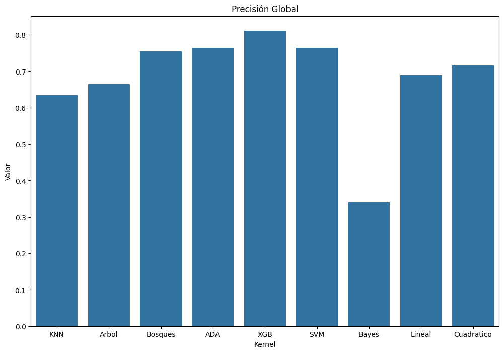

```python
p_global = pd.DataFrame({
  'Kernel' : ["KNN", "Arbol", "Bosques", "ADA", "XGB", "SVM", "Bayes", "Lineal", "Cuadratico"],
  'Valor'  : [
    indices_knn["Precisión Global"],
    indices_arbol["Precisión Global"],
    indices_bosques["Precisión Global"],
    indices_potenciacion["Precisión Global"],
    indices_xg_potenciacion["Precisión Global"],
    indices_svm["Precisión Global"],
    indices_bayes["Precisión Global"],
    indices_dis_lineal["Precisión Global"],
    indices_dis_cuadratico["Precisión Global"]
  ]
})
fig, ax = plt.subplots(figsize = (12, 8))
no_print = sns.barplot(x = 'Kernel', y = 'Valor', data = p_global)
no_print = plt.title("Precisión Global")
plt.show()
```

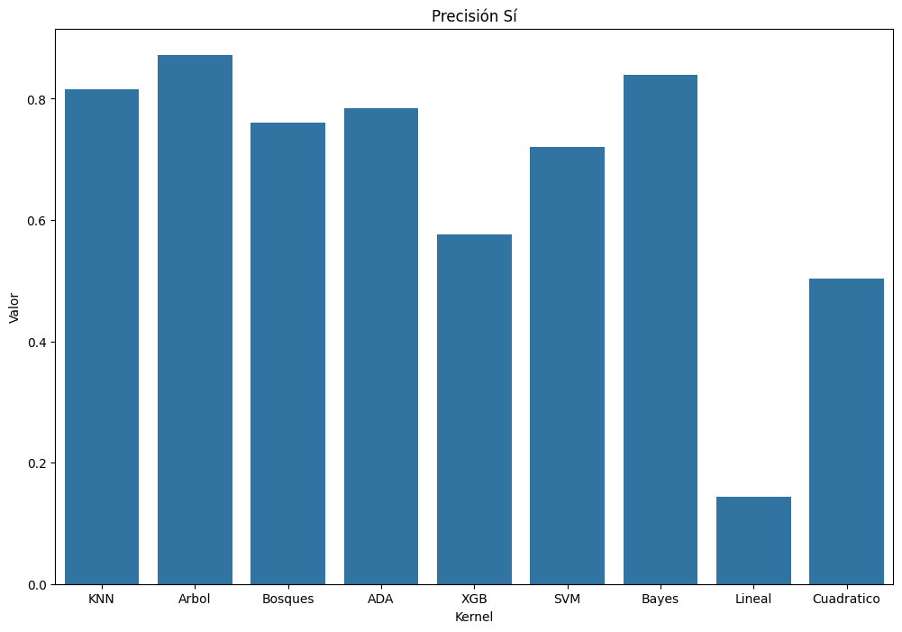

```python
p_si = pd.DataFrame({
  'Kernel' : ["KNN", "Arbol", "Bosques", "ADA", "XGB", "SVM", "Bayes", "Lineal", "Cuadratico"],
  'Valor'  : [
    indices_knn['Precisión por categoría']["yes"][0],
    indices_arbol['Precisión por categoría']["yes"][0],
    indices_bosques['Precisión por categoría']["yes"][0],
    indices_potenciacion['Precisión por categoría']["yes"][0],
    indices_xg_potenciacion['Precisión por categoría']["yes"][0],
    indices_svm['Precisión por categoría']["yes"][0],
    indices_bayes['Precisión por categoría']["yes"][0],
    indices_dis_lineal['Precisión por categoría']["yes"][0],
    indices_dis_cuadratico['Precisión por categoría']["yes"][0]
  ]
})
fig, ax = plt.subplots(figsize = (12, 8))
no_print = sns.barplot(x = 'Kernel', y = 'Valor', data = p_si)
no_print = plt.title("Precisión Sí")
plt.show()
```

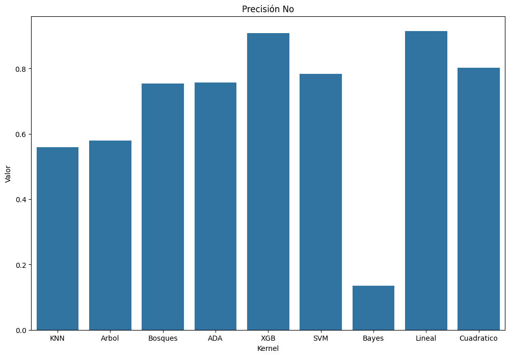

```python
p_no = pd.DataFrame({
  'Kernel' : ["KNN", "Arbol", "Bosques", "ADA", "XGB", "SVM", "Bayes", "Lineal", "Cuadratico"],
  'Valor'  : [
    indices_knn['Precisión por categoría']["no"][0],
    indices_arbol['Precisión por categoría']["no"][0],
    indices_bosques['Precisión por categoría']["no"][0],
    indices_potenciacion['Precisión por categoría']["no"][0],
    indices_xg_potenciacion['Precisión por categoría']["no"][0],
    indices_svm['Precisión por categoría']["no"][0],
    indices_bayes['Precisión por categoría']["no"][0],
    indices_dis_lineal['Precisión por categoría']["no"][0],
    indices_dis_cuadratico['Precisión por categoría']["no"][0]
  ]
})
fig, ax = plt.subplots(figsize = (12, 8))
no_print = sns.barplot(x = 'Kernel', y = 'Valor', data = p_no)
no_print = plt.title("Precisión No")
plt.show()
```

#### Tabla Indices

```python
ultimos_indices = [indices_knn,
                   indices_arbol,
                   indices_bosques,
                   indices_potenciacion,
                   indices_xg_potenciacion,
                   indices_svm,
                   indices_bayes,
                   indices_dis_lineal,
                   indices_dis_cuadratico]
nombre_modelos = ["KNN", "DecisionTreeClassifier", "RandomForestClassifier", "AdaBoostClassifier", "XGB", "SVM", "Bayes", "LDA", "QDA"]
```

```python
df_todos_los_indices = pd.DataFrame()
for i, indice in enumerate(ultimos_indices):
    df = pd.DataFrame({
        'Modelo': [nombre_modelos[i]],
        'Precisión Global': [indice['Precisión Global']],
        'Error Global': [indice['Error Global']],
        'Precisión Positiva (PP)': [indice['Precisión por categoría']['yes'].iloc[0]],
        'Precisión Negativa (PN)': [indice['Precisión por categoría']['no'].iloc[0]]
    })
    df_todos_los_indices = pd.concat([df_todos_los_indices, df], ignore_index=True)
df_todos_los_indices
```

|  | Modelo | Precisión Global | Error Global | Precisión Positiva (PP) | Precisión Negativa (PN) |
| --- | --- | --- | --- | --- | --- |
| 0 | KNN | 0.634033 | 0.365967 | 0.816 | 0.559211 |
| 1 | DecisionTreeClassifier | 0.664336 | 0.335664 | 0.872 | 0.578947 |
| 2 | RandomForestClassifier | 0.755245 | 0.244755 | 0.760 | 0.753289 |
| 3 | AdaBoostClassifier | 0.764569 | 0.235431 | 0.784 | 0.756579 |
| 4 | XGB | 0.811189 | 0.188811 | 0.576 | 0.907895 |
| 5 | SVM | 0.764569 | 0.235431 | 0.720 | 0.782895 |
| 6 | Bayes | 0.340326 | 0.659674 | 0.840 | 0.134868 |
| 7 | LDA | 0.689977 | 0.310023 | 0.144 | 0.914474 |
| 8 | QDA | 0.715618 | 0.284382 | 0.504 | 0.802632 |

**Interpretacion**

- Al comparar los modelos anteriores de clasificación, denotamos que como el "problema a resolver es la fuga de talento" el modelo más afin para este problema debería de tener un porcentaje alto de Precisión Positiva, sin sacrificar demasiado PN, entonces, el "mejor" según los índices sería: `AdaBoostClassifier` xq tiene un buen balnce entre los indices de errores.

| Modelo | PG | EG | PP | PN |
| --- | --- | --- | --- | --- |
| AdaBoostClassifier | 0.764569 | 0.235431 | 0.784 | 0.756579 |

Aunque no es el mejor porcentaje de PP, es el que mejor mantiene un balance y ademas no sacrifica los otros indices.

## Parte 3

- c) Guarde el mejor modelo en un archivo.

↑ Volver al Menú

```python
modelo = Pipeline(steps=[
  ('preprocesador', preprocesamiento),
  ('clasificador', AdaBoostClassifier(n_estimators=21, learning_rate = 0.1, estimator = DecisionTreeClassifier(max_depth=3)))
])
noimprimir = modelo.fit(X, y)
```

```python
import pickle

with open("modelo_AdaBoostingClassifier.pkl", 'wb') as file:
  pickle.dump(modelo, file)
```

# Ejercicio 2

[40 puntos] En este ejercicio se usará la tabla de datos `concreto_v1.csv`. Este conjunto de datos contiene mediciones de los distintos componentes de una estructura de concreto. El concreto es el material más importante en la ingeniería civil. La idea es poder predecir o calcular el valor de resistencia de compresión del concreto.

Las variables de la tabla de datos son las siguientes:

- `cemento`: Kilogramos de cemento en metro cúbico de mezcla.
- `escoria`: Kilogramos de escoria de alto horno en metro cúbico de mezcla.
- `ceniza_volatil`: Kilogramos de ceniza volátil en metro cúbico de mezcla.
- `agua`: Kilogramos de agua en metro cúbico de mezcla.
- `super_plastificante`: Kilogramos de superplastificante en metro cúbico de mezcla.
- `agregado_grueso`: Kilogramos de agregado grueso en metro cúbico de mezcla.
- `agregado_fino`: Kilogramos de agregado fino en metro cúbico de mezcla.
- `edad`: Días (1 - 365).
- `resistencia_compresion`: Resistencia a la compresión del concreto (variable a predecir).

Realice lo siguiente:

- a) El objetivo de este ejercicio es comparar todos los métodos de regresión vistos en el curso con esta tabla de datos. Para esto, genere una Validación Cruzada con 10 grupos para los métodos `Regresión lineal simple`, `Regresión Múltiple`, `Regresión Lasso`, `Regresión Ridge`, `SVM`, `Árboles`, `Bosques` y `Potenciación` (en teoría se deberían calibrar todos los métodos).
- b) Construya un DataFrame que compare los modelos generados en el ítem anterior. Para esto en cada una de las filas debe aparecer un modelo predictivo y en las columnas aparezcan el índice de `Raíz del error cuadrático medio` e interpréte los resultados. Cuál de los modelos es mejor para estos datos y por qué?, recuerde comparar contra el resumen numérico de la variable a predecir.
- c) Guarde el mejor modelo en un archivo.

↑ Volver al Menú

### Exploración de los Datos

#### Carga Datos

```python
df = pd.read_csv("../concreto_v1.csv")
df
```

|  | cemento | escoria | ceniza_volatil | agua | super_plastificante | agregado_grueso | agregado_fino | edad | resistencia_compresion |
| --- | --- | --- | --- | --- | --- | --- | --- | --- | --- |
| 0 | 540.0 | 0.0 | 0.0 | 162.0 | 2.5 | 1040.0 | 676.0 | 28 | 79.99 |
| 1 | 540.0 | 0.0 | 0.0 | 162.0 | 2.5 | 1055.0 | 676.0 | 28 | 61.89 |
| 2 | 332.5 | 142.5 | 0.0 | 228.0 | 0.0 | 932.0 | 594.0 | 270 | 40.27 |
| 3 | 332.5 | 142.5 | 0.0 | 228.0 | 0.0 | 932.0 | 594.0 | 365 | 41.05 |
| 4 | 198.6 | 132.4 | 0.0 | 192.0 | 0.0 | 978.4 | 825.5 | 360 | 44.30 |
| ... | ... | ... | ... | ... | ... | ... | ... | ... | ... |
| 1025 | 276.4 | 116.0 | 90.3 | 179.6 | 8.9 | 870.1 | 768.3 | 28 | 44.28 |
| 1026 | 322.2 | 0.0 | 115.6 | 196.0 | 10.4 | 817.9 | 813.4 | 28 | 31.18 |
| 1027 | 148.5 | 139.4 | 108.6 | 192.7 | 6.1 | 892.4 | 780.0 | 28 | 23.70 |
| 1028 | 159.1 | 186.7 | 0.0 | 175.6 | 11.3 | 989.6 | 788.9 | 28 | 32.77 |
| 1029 | 260.9 | 100.5 | 78.3 | 200.6 | 8.6 | 864.5 | 761.5 | 28 | 32.40 |

1030 rows × 9 columns

```python
df.info()
```

```
<class 'pandas.core.frame.DataFrame'>
RangeIndex: 1030 entries, 0 to 1029
Data columns (total 9 columns):
 #   Column                  Non-Null Count  Dtype
---  ------                  --------------  -----
 0   cemento                 1030 non-null   float64
 1   escoria                 1030 non-null   float64
 2   ceniza_volatil          1030 non-null   float64
 3   agua                    1030 non-null   float64
 4   super_plastificante     1030 non-null   float64
 5   agregado_grueso         1030 non-null   float64
 6   agregado_fino           1030 non-null   float64
 7   edad                    1030 non-null   int64
 8   resistencia_compresion  1030 non-null   float64
dtypes: float64(8), int64(1)
memory usage: 72.5 KB
```

```python
df.isnull().sum()
```

```
cemento                   0
escoria                   0
ceniza_volatil            0
agua                      0
super_plastificante       0
agregado_grueso           0
agregado_fino             0
edad                      0
resistencia_compresion    0
dtype: int64
```

#### Distribución de Variable a Predecir

```python
df['resistencia_compresion'].describe()
```

```
count    1030.000000
mean       35.817961
std        16.705742
min         2.330000
25%        23.710000
50%        34.445000
75%        46.135000
max        82.600000
Name: resistencia_compresion, dtype: float64
```

Datos de la Variable a predecir `resistencia_compresion`

- Máximo: Valor máximo de la variable a predecir es `82.6`.
- 1er cuartil (Q1) 25%: de los datos es menor que o igual a `23.71`.
- 2do cuartil (Q2) La mediana. 50%: de los datos es menor que o igual a `34.445`.
- 3er cuartil (Q3) 75%: de los datos es menor que o igual a `46.135`.
- Rango intercuartíl: La distancia es `22.424999999999997`; de esta manera, abarca el 50% central de los datos.
- Mínimo: Valor mínimo de la variable a predecir es `2.33`.

#### Distribución de Variable predictoras

```python
def desVarNum(VarPred):
  Cuartil = statistics.quantiles(VarPred)
  val_max = np.max(VarPred)
  val_min = np.min(VarPred)
  return {"Máximo": val_max, "Cuartiles": Cuartil, "Mínimo": val_min}

for col in df.columns:
    if col != 'resistencia_compresion':
        print(f"{col}: \n{desVarNum(df[col])}\n")
```

```
cemento:
{'Máximo': np.float64(540.0), 'Cuartiles': [192.0, 272.9, 350.0], 'Mínimo': np.float64(102.0)}

escoria:
{'Máximo': np.float64(359.4), 'Cuartiles': [0.0, 22.0, 143.0], 'Mínimo': np.float64(0.0)}

ceniza_volatil:
{'Máximo': np.float64(200.1), 'Cuartiles': [0.0, 0.0, 118.3], 'Mínimo': np.float64(0.0)}

agua:
{'Máximo': np.float64(247.0), 'Cuartiles': [164.9, 185.0, 192.0], 'Mínimo': np.float64(121.8)}

super_plastificante:
{'Máximo': np.float64(32.2), 'Cuartiles': [0.0, 6.4, 10.2], 'Mínimo': np.float64(0.0)}

agregado_grueso:
{'Máximo': np.float64(1145.0), 'Cuartiles': [932.0, 968.0, 1029.4], 'Mínimo': np.float64(801.0)}

agregado_fino:
{'Máximo': np.float64(992.6), 'Cuartiles': [730.3, 779.5, 824.25], 'Mínimo': np.float64(594.0)}

edad:
{'Máximo': np.int64(365), 'Cuartiles': [7.0, 28.0, 56.0], 'Mínimo': np.int64(1)}
```

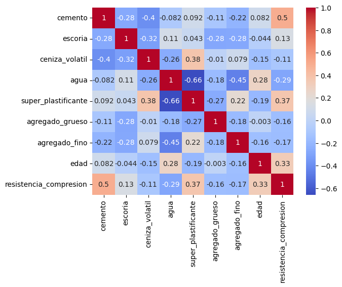

```python
sns.heatmap(df.corr(), annot=True, cmap='coolwarm')
plt.show()
```

### Division datos (X|y)

```python
X = df.drop(columns=['resistencia_compresion'])
print(f"X:\n{X.head(3)}")

y = df['resistencia_compresion'].to_numpy()
print(f"\ny:\n{y[:6]}")
```

```
X:
   cemento  escoria  ceniza_volatil   agua  super_plastificante  \
0    540.0      0.0             0.0  162.0                  2.5
1    540.0      0.0             0.0  162.0                  2.5
2    332.5    142.5             0.0  228.0                  0.0

   agregado_grueso  agregado_fino  edad
0           1040.0          676.0    28
1           1055.0          676.0    28
2            932.0          594.0   270

y:
[79.99 61.89 40.27 41.05 44.3  47.03]
```

```python
# var_categorical = 'department', 'salary', 'bonus_yes', 'bonus_no', 'promoted_yes', 'promoted_no'
# var_numerical = 'review', 'projects', 'tenure', 'satisfaction', 'avg_hrs_month'

# # labels = ['no', 'yes'] # de target
```

### Preprocesamiento

```python
var_numerical = X.columns
preprocesamiento = ColumnTransformer(
  transformers=[
    # ('cat', OneHotEncoder(sparse_output = False), var_categorical),
    ('num', StandardScaler(), var_numerical)
  ]
)
preprocesamiento
```

```
ColumnTransformer(transformers=[('num', StandardScaler(),
                                 Index(['cemento', 'escoria', 'ceniza_volatil', 'agua', 'super_plastificante',
       'agregado_grueso', 'agregado_fino', 'edad'],
      dtype='object'))])
```

```python
def errores_reg(y_true, y_predicted):
    y_true = np.array(y_true)
    y_predicted = np.array(y_predicted)
    MSE0 = np.sum(np.square(y_true - y_predicted))
    RMSE = math.sqrt(MSE0 / (len(y_true)))
    MAE0 = np.sum(np.abs(y_true - y_predicted))
    MAE = MAE0 / (len(y_true))
    EN = np.sum(np.abs(y_true - y_predicted))
    ED = np.sum(np.abs(y_true))
    ER = EN / ED
    df = pd.DataFrame({'RMSE' : [RMSE], 'MAE' : [MAE], 'ER' : [ER]})
    return df
```

```python
def imp_resultados_rmse(kernel_list, rmse_list):
  res_svr = pd.DataFrame({
    'Nucleo': kernel_list,
    'RMSE': rmse_list
  })
  return res_svr
```

## Parte 1

- a) El objetivo de este ejercicio es comparar todos los métodos de regresión vistos en el curso con esta tabla de datos. Para esto, genere una Validación Cruzada con 10 grupos para los métodos `Regresión lineal simple`, `Regresión Múltiple`, `Regresión Lasso`, `Regresión Ridge`, `SVM`, `Árboles`, `Bosques` y `Potenciación` (en teoría se deberían calibrar todos los métodos).

↑ Volver al Menú

#### **Linear Regression Simple**

```python
kfold = KFold(n_splits=10, shuffle=True, random_state=42)
rmse_agua = 0
rmse_cemento = 0
rmse_edad = 0

for train, test in kfold.split(X, y):

    tam_test = y[test].size

    # === Regresión lineal simple: agua ===
    modelo_lrs_agua = LinearRegression()

    X_train = X.iloc[train][['agua']]
    X_test  = X.iloc[test][['agua']]

    modelo_lrs_agua.fit(X_train, y[train])
    pred_fold = modelo_lrs_agua.predict(X_test)

    rmse_agua += np.sqrt(
        (1 / tam_test) * np.sum((y[test] - pred_fold) ** 2)
    )
    # === Regresión lineal simple: cemento ===
    modelo_lrs_cemento = LinearRegression()

    X_train = X.iloc[train][['cemento']]
    X_test  = X.iloc[test][['cemento']]

    modelo_lrs_cemento.fit(X_train, y[train])
    pred_fold = modelo_lrs_cemento.predict(X_test)

    rmse_cemento += np.sqrt(
        (1 / tam_test) * np.sum((y[test] - pred_fold) ** 2)
    )
    # === Regresión lineal simple: edad ===
    modelo_lrs_edad = LinearRegression()

    X_train = X.iloc[train][['edad']]
    X_test  = X.iloc[test][['edad']]

    modelo_lrs_edad.fit(X_train, y[train])
    pred_fold = modelo_lrs_edad.predict(X_test)

    rmse_edad += np.sqrt(
        (1 / tam_test) * np.sum((y[test] - pred_fold) ** 2)
    )

rmse_agua = rmse_agua / 10
rmse_cemento = rmse_cemento / 10
rmse_edad = rmse_edad / 10

print(rmse_agua)
print(rmse_cemento)
print(rmse_edad)
```

```
15.966761040196804
14.501690242759405
15.759673689526988
```

##### Evaluación

```python
variable_usada = ['agua', 'cemento', 'edad']
lista_lrs = [rmse_agua, rmse_cemento, rmse_edad]

resultados_lrs = imp_resultados_rmse(variable_usada, lista_lrs).sort_values(by='RMSE')
resultados_lrs
```

|  | Nucleo | RMSE |
| --- | --- | --- |
| 1 | cemento | 14.501690 |
| 2 | edad | 15.759674 |
| 0 | agua | 15.966761 |

##### Gráficos

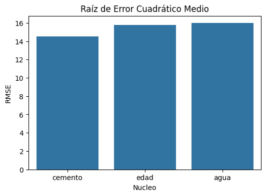

```python
def imp_grafico_rmse(lista_resultados_rmse):
  fig, ax = plt.subplots(figsize = (6, 4))
  no_imprimir = sns.barplot(x = 'Nucleo', y = 'RMSE', data = lista_resultados_rmse)
  no_imprimir = plt.title("Raíz de Error Cuadrático Medio")
  plt.show()

imp_grafico_rmse(resultados_lrs)
```

#### **Linear Regression Multiple**

```python
kfold = KFold(n_splits = 10, shuffle = True)
rmse_multiple = 0

for train, test in kfold.split(X, y):
    tam_test = y[test].size

    # === Regresión Lineal Múltiple ===
    modelo_rlm = Pipeline(steps=[
        ('preprocesador', preprocesamiento),
        ('regresor', LinearRegression())
    ])

    X_train = X.iloc[train][var_numerical]
    X_test  = X.iloc[test][var_numerical]

    modelo_rlm.fit(X_train, y[train])
    pred_fold = modelo_rlm.predict(X_test)

    rmse_multiple += np.sqrt(
        (1 / tam_test) * np.sum((y[test] - pred_fold) ** 2)
    )

rmse_rlm = rmse_multiple / 10

print(rmse_rlm)
```

```
10.441237840272006
```

##### Evaluación

```python
variable_usada = ['Regresión Lineal Múltiple']
lista_rlm = [rmse_rlm]

resultados_rlm = imp_resultados_rmse(variable_usada, lista_rlm).sort_values(by='RMSE')
resultados_rlm
```

|  | Nucleo | RMSE |
| --- | --- | --- |
| 0 | Regresión Lineal Múltiple | 10.441238 |

#### **Lasso**

```python
def mejor_alpha(X, y, train):
    rango_alpha = np.logspace(-6, 6, 200)
    modelo = Pipeline(steps=[
    ('preprocesador', preprocesamiento),
    ('clasificador', LassoCV(alphas = rango_alpha))
    ])
    modelo.fit(X.iloc[train], y[train])
    mejor_alpha = modelo['clasificador'].alpha_
    return mejor_alpha
```

```python
kfold = KFold(n_splits = 10, shuffle = True)
rmse_modelo1   = 0
rmse_modelo2  = 0
rmse_modelo3      = 0

for train, test in kfold.split(X, y):
  tam_test = y[test].size

  # modelo1_mejor_alpha
  mejor_alfa = mejor_alpha(X, y, train)
  modelo_lasso = Pipeline(steps=[
    ('preprocesador', preprocesamiento),
    ('clasificador', Lasso(alpha = mejor_alfa))
  ])
  noimprimir = modelo_lasso.fit(X.iloc[train], y[train])
  pred_fold   = modelo_lasso.predict(X.iloc[test])
  rmse_modelo1 = rmse_modelo1 + np.sqrt((1/tam_test)*np.sum(np.square(y[test] - pred_fold)))

rmse_modelo1 = rmse_modelo1 / 10


print(rmse_modelo1)
```

```
10.440267372583266
```

##### Evaluación

```python
alfa = ['mejor_alfa']
lista_lasso = [rmse_modelo1]

resultados_lasso = imp_resultados_rmse(alfa, lista_lasso)
resultados_lasso
```

|  | Nucleo | RMSE |
| --- | --- | --- |
| 0 | mejor_alfa | 10.440267 |

#### **Ridge**

```python
def mejor_alpha_ridge(X, y, train):
    rango_alpha = np.logspace(-6, 6, 200)
    modelo = Pipeline(steps=[
    ('preprocesador', preprocesamiento),
    ('clasificador', RidgeCV(alphas = rango_alpha))
    ])
    modelo.fit(X.iloc[train], y[train])
    mejor_alpha_ridge = modelo['clasificador'].alpha_
    return mejor_alpha_ridge
```

```python
kfold = KFold(n_splits = 10, shuffle = True)
rmse_svd       = 0
rmse_cholesky  = 0
rmse_lsqr      = 0
rmse_sparse_cg = 0
rmse_sag       = 0

for train, test in kfold.split(X, y):
  tam_test = y[test].size

  # svd
  best_alpha_ridge = mejor_alpha_ridge(X, y, train)
  modelo = Pipeline(steps=[
    ('preprocesador', preprocesamiento),
    ('clasificador', Ridge(alpha = best_alpha_ridge, solver = "svd"))
  ])
  noimprimir  = modelo.fit(X.iloc[train], y[train])
  pred_fold   = modelo.predict(X.iloc[test])
  rmse_svd = rmse_svd + np.sqrt((1/tam_test)*np.sum(np.square(y[test] - pred_fold)))

  # cholesky
  best_alpha_ridge = mejor_alpha_ridge(X, y, train)
  modelo = Pipeline(steps=[
    ('preprocesador', preprocesamiento),
    ('clasificador', Ridge(alpha = best_alpha_ridge, solver = "cholesky"))
  ])
  noimprimir = modelo.fit(X.iloc[train], y[train])
  pred_fold  = modelo.predict(X.iloc[test])
  rmse_cholesky = rmse_cholesky + np.sqrt((1/tam_test)*np.sum(np.square(y[test] - pred_fold)))

  # lsqr
  best_alpha_ridge = mejor_alpha_ridge(X, y, train)
  modelo = Pipeline(steps=[
    ('preprocesador', preprocesamiento),
    ('clasificador', Ridge(alpha = best_alpha_ridge, solver = "lsqr"))
  ])
  noimprimir = modelo.fit(X.iloc[train], y[train])
  pred_fold  = modelo.predict(X.iloc[test])
  rmse_lsqr = rmse_lsqr + np.sqrt((1/tam_test)*np.sum(np.square(y[test] - pred_fold)))

  # sparse_cg
  best_alpha_ridge = mejor_alpha_ridge(X, y, train)
  modelo = Pipeline(steps=[
    ('preprocesador', preprocesamiento),
    ('clasificador', Ridge(alpha = best_alpha_ridge, solver = "sparse_cg"))
  ])
  noimprimir = modelo.fit(X.iloc[train], y[train])
  pred_fold  = modelo.predict(X.iloc[test])
  rmse_sparse_cg = rmse_sparse_cg + np.sqrt((1/tam_test)*np.sum(np.square(y[test] - pred_fold)))

  # sag
  best_alpha_ridge = mejor_alpha_ridge(X, y, train)
  modelo = Pipeline(steps=[
    ('preprocesador', preprocesamiento),
    ('clasificador', Ridge(alpha = best_alpha_ridge, solver = "sag"))
  ])
  noimprimir = modelo.fit(X.iloc[train], y[train])
  pred_fold  = modelo.predict(X.iloc[test])
  rmse_sag = rmse_sag + np.sqrt((1/tam_test)*np.sum(np.square(y[test] - pred_fold)))

# Se debe promediar el error cometido en los 10 grupos,
# se divide entre 10 pues n_splits = 10
rmse_svd = rmse_svd / 10
rmse_cholesky = rmse_cholesky / 10
rmse_lsqr = rmse_lsqr / 10
rmse_sparse_cg = rmse_sparse_cg / 10
rmse_sag = rmse_sag / 10

# rmse_svd
# rmse_cholesky
# rmse_lsqr
# rmse_sparse_cg
# rmse_sag
```

##### Evaluación

```python
solver = ['svd', 'cholesky', 'lsqr', 'sparse_cg', 'sag']
lista_ridge = [rmse_svd, rmse_cholesky, rmse_lsqr, rmse_sparse_cg, rmse_sag]

resultados_ridge = imp_resultados_rmse(solver, lista_ridge)
resultados_ridge
```

|  | Nucleo | RMSE |
| --- | --- | --- |
| 0 | svd | 10.467661 |
| 1 | cholesky | 10.467661 |
| 2 | lsqr | 10.467650 |
| 3 | sparse_cg | 10.467650 |
| 4 | sag | 10.467656 |

##### Gráfico

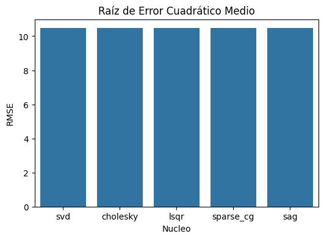

```python
imp_grafico_rmse(resultados_ridge)
```

#### **Support Vector Machine para Regresión**

```python
kfold = KFold(n_splits = 10, shuffle = True)
rmse_linear = 0
rmse_rbf    = 0
rmse_poly   = 0

for train, test in kfold.split(X, y):
  tam_test = y[test].size
  # sigmoid
  modelo = Pipeline(steps=[
    ('preprocesador', preprocesamiento),
    ('clasificador', SVR(kernel = 'linear', C=100, epsilon=0.1))
  ])
  noimprimir  = modelo.fit(X.iloc[train], y[train])
  pred_fold   = modelo.predict(X.iloc[test])
  rmse_linear = rmse_linear + np.sqrt((1/tam_test)*np.sum(np.square(y[test] - pred_fold)))

  # rbf
  modelo = Pipeline(steps=[
    ('preprocesador', preprocesamiento),
    ('clasificador', SVR(kernel = 'rbf', C=100, epsilon=0.1))
  ])
  noimprimir = modelo.fit(X.iloc[train], y[train])
  pred_fold  = modelo.predict(X.iloc[test])
  rmse_rbf   = rmse_rbf + np.sqrt((1/tam_test)*np.sum(np.square(y[test] - pred_fold)))

  # poly
  modelo = Pipeline(steps=[
    ('preprocesador', preprocesamiento),
    ('clasificador', SVR(kernel = 'poly', C=100, epsilon=0.1))
  ])
  noimprimir = modelo.fit(X.iloc[train], y[train])
  pred_fold  = modelo.predict(X.iloc[test])
  rmse_poly  = rmse_poly + np.sqrt((1/tam_test)*np.sum(np.square(y[test] - pred_fold)))

# Se debe promediar el error cometido en los 10 grupos,
# se divide entre 10 pues n_splits = 10
rmse_linear = rmse_linear / 10
rmse_rbf = rmse_rbf / 10
rmse_poly = rmse_poly / 10

print(rmse_linear)
print(rmse_rbf)
print(rmse_poly)
```

```
10.964836600691722
5.687605252591206
9.31480235122796
```

##### Evaluación

```python
kernel = ['linear', 'rbf', 'poly']
lista_svc = [rmse_linear, rmse_rbf, rmse_poly]

resultados_svr = imp_resultados_rmse(kernel, lista_svc)
resultados_svr
```

|  | Nucleo | RMSE |
| --- | --- | --- |
| 0 | linear | 10.964837 |
| 1 | rbf | 5.687605 |
| 2 | poly | 9.314802 |

##### Gráfico

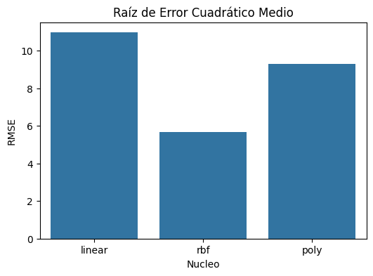

```python
imp_grafico_rmse(resultados_svr)
```

##### Resultados

- Se utilizara el rbf con menor REMS.

#### **RandomForestRegressor**

```python
kfold = KFold(n_splits = 10, shuffle = True)
rmse_squared_error  = 0
rmse_absolute_error = 0
rmse_friedman_mse   = 0
rmse_poisson        = 0

for train, test in kfold.split(X, y):
  tam_test = y[test].size

  # squared_error
  modelo = Pipeline(steps=[
    ('preprocesador', preprocesamiento),
    ('clasificador', RandomForestRegressor(max_depth=20, n_estimators = 40, criterion = "squared_error"))
  ])
  noimprimir  = modelo.fit(X.iloc[train], y[train])
  pred_fold   = modelo.predict(X.iloc[test])
  rmse_squared_error = rmse_squared_error + np.sqrt((1/tam_test)*np.sum(np.square(y[test] - pred_fold)))

  # absolute_error
  modelo = Pipeline(steps=[
    ('preprocesador', preprocesamiento),
    ('clasificador', RandomForestRegressor(max_depth=20, n_estimators = 40, criterion = "absolute_error"))
  ])
  noimprimir = modelo.fit(X.iloc[train], y[train])
  pred_fold  = modelo.predict(X.iloc[test])
  rmse_absolute_error = rmse_absolute_error + np.sqrt((1/tam_test)*np.sum(np.square(y[test] - pred_fold)))

  # friedman_mse
  modelo = Pipeline(steps=[
    ('preprocesador', preprocesamiento),
    ('clasificador', RandomForestRegressor(max_depth=20, n_estimators = 40, criterion = "friedman_mse"))
  ])
  noimprimir = modelo.fit(X.iloc[train], y[train])
  pred_fold  = modelo.predict(X.iloc[test])
  rmse_friedman_mse = rmse_friedman_mse + np.sqrt((1/tam_test)*np.sum(np.square(y[test] - pred_fold)))

  # rmse_poisson
  modelo = Pipeline(steps=[
    ('preprocesador', preprocesamiento),
    ('clasificador', RandomForestRegressor(max_depth=20, n_estimators = 40, criterion = "poisson"))
  ])
  noimprimir = modelo.fit(X.iloc[train], y[train])
  pred_fold  = modelo.predict(X.iloc[test])
  rmse_poisson = rmse_poisson + np.sqrt((1/tam_test)*np.sum(np.square(y[test] - pred_fold)))

# Se debe promediar el error cometido en los 10 grupos,
# se divide entre 10 pues n_splits = 10
rmse_squared_error = rmse_squared_error / 10
rmse_absolute_error = rmse_absolute_error / 10
rmse_friedman_mse = rmse_friedman_mse / 10
rmse_poisson = rmse_poisson / 10

# rmse_squared_error
# rmse_absolute_error
# rmse_friedman_mse
# rmse_poisson
```

##### Evaluación

```python
criterion = ['squared_error', 'absolute_error', 'friedman_mse', 'poisson']
lista_rfr = [rmse_squared_error, rmse_absolute_error, rmse_friedman_mse, rmse_poisson]

resultados_rfr = imp_resultados_rmse(criterion, lista_rfr).sort_values(by='RMSE')
resultados_rfr
```

|  | Nucleo | RMSE |
| --- | --- | --- |
| 1 | absolute_error | 4.654530 |
| 0 | squared_error | 4.738506 |
| 3 | poisson | 4.787082 |
| 2 | friedman_mse | 4.807452 |

##### Gráfico

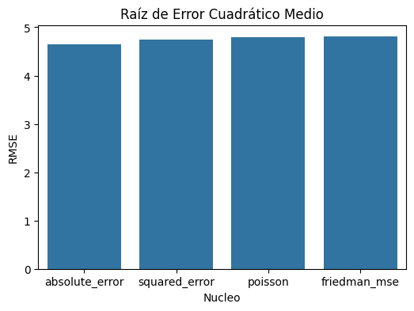

```python
imp_grafico_rmse(resultados_rfr)
```

##### Resultados

- Se utilizara el absolute_error con menor RMSE.

#### **Decision Tree Regressor**

```python
kfold = KFold(n_splits = 10, shuffle = True)
rmse_squared_error_dtr  = 0
rmse_absolute_error_dtr = 0
rmse_friedman_mse_dtr   = 0
rmse_poisson_dtr        = 0

for train, test in kfold.split(X, y):
  tam_test = y[test].size

  # squared_error
  modelo = Pipeline(steps=[
    ('preprocesador', preprocesamiento),
    ('clasificador', DecisionTreeRegressor(max_depth = 3, criterion = "squared_error"))
  ])
  noimprimir  = modelo.fit(X.iloc[train], y[train])
  pred_fold   = modelo.predict(X.iloc[test])
  rmse_squared_error_dtr = rmse_squared_error_dtr + np.sqrt((1/tam_test)*np.sum(np.square(y[test] - pred_fold)))

  # absolute_error
  modelo = Pipeline(steps=[
    ('preprocesador', preprocesamiento),
    ('clasificador', DecisionTreeRegressor(max_depth = 3, criterion = "absolute_error"))
  ])
  noimprimir = modelo.fit(X.iloc[train], y[train])
  pred_fold  = modelo.predict(X.iloc[test])
  rmse_absolute_error_dtr = rmse_absolute_error_dtr + np.sqrt((1/tam_test)*np.sum(np.square(y[test] - pred_fold)))

  # friedman_mse
  modelo = Pipeline(steps=[
    ('preprocesador', preprocesamiento),
    ('clasificador', DecisionTreeRegressor(max_depth = 3, criterion = "friedman_mse"))
  ])
  noimprimir = modelo.fit(X.iloc[train], y[train])
  pred_fold  = modelo.predict(X.iloc[test])
  rmse_friedman_mse_dtr = rmse_friedman_mse_dtr + np.sqrt((1/tam_test)*np.sum(np.square(y[test] - pred_fold)))

  # rmse_poisson_dtr
  modelo = Pipeline(steps=[
    ('preprocesador', preprocesamiento),
    ('clasificador', DecisionTreeRegressor(max_depth = 3, criterion = "poisson"))
  ])
  noimprimir = modelo.fit(X.iloc[train], y[train])
  pred_fold  = modelo.predict(X.iloc[test])
  rmse_poisson_dtr = rmse_poisson_dtr + np.sqrt((1/tam_test)*np.sum(np.square(y[test] - pred_fold)))

# Se debe promediar el error cometido en los 10 grupos,
# se divide entre 10 pues n_splits = 10
rmse_squared_error_dtr = rmse_squared_error_dtr / 10
rmse_absolute_error_dtr = rmse_absolute_error_dtr / 10
rmse_friedman_mse_dtr = rmse_friedman_mse_dtr / 10
rmse_poisson_dtr = rmse_poisson_dtr / 10

print(rmse_squared_error_dtr)
print(rmse_absolute_error_dtr)
print(rmse_friedman_mse_dtr)
print(rmse_poisson_dtr)
```

```
10.352000445330264
10.671259291551072
10.352000445330265
10.600949071267902
```

##### Evaluación

```python
criterion = ['squared_error', 'absolute_error', 'friedman_mse', 'poisson']
lista_dtr = [rmse_squared_error_dtr, rmse_absolute_error_dtr, rmse_friedman_mse_dtr, rmse_poisson_dtr]

resultados_dtr = imp_resultados_rmse(criterion, lista_dtr).sort_values(by='RMSE')
resultados_dtr
```

|  | Nucleo | RMSE |
| --- | --- | --- |
| 0 | squared_error | 10.352000 |
| 2 | friedman_mse | 10.352000 |
| 3 | poisson | 10.600949 |
| 1 | absolute_error | 10.671259 |

##### Gráfico

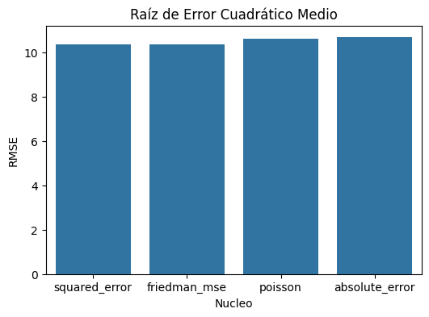

```python
imp_grafico_rmse(resultados_dtr)
```

#### **Potenciacion**

```python
kfold = KFold(n_splits = 10, shuffle = True)
rmse_squared_error_gb  = 0
rmse_friedman_mse_gb   = 0

for train, test in kfold.split(X, y):
  tam_test = y[test].size

  # squared_error
  modelo = Pipeline(steps=[
    ('preprocesador', preprocesamiento),
    ('clasificador', GradientBoostingRegressor(n_estimators = 40, max_depth = 3, criterion= "squared_error"))
  ])
  noimprimir  = modelo.fit(X.iloc[train], y[train])
  pred_fold   = modelo.predict(X.iloc[test])
  rmse_squared_error_gb = rmse_squared_error_gb + np.sqrt((1/tam_test)*np.sum(np.square(y[test] - pred_fold)))

   # friedman_mse
  modelo = Pipeline(steps=[
    ('preprocesador', preprocesamiento),
    ('clasificador', GradientBoostingRegressor(n_estimators = 40, max_depth = 3, criterion= "friedman_mse"))
  ])
  noimprimir = modelo.fit(X.iloc[train], y[train])
  pred_fold  = modelo.predict(X.iloc[test])
  rmse_friedman_mse_gb = rmse_friedman_mse_gb + np.sqrt((1/tam_test)*np.sum(np.square(y[test] - pred_fold)))


rmse_squared_error_gb = rmse_squared_error_gb / 10
rmse_friedman_mse_gb = rmse_friedman_mse_gb / 10

print(rmse_squared_error_gb)
print(rmse_friedman_mse_gb)
```

```
6.183554438413304
6.1833594198306425
```

##### Evaluación

```python
criterion = ['squared_error', 'friedman_mse']
lista_gb = [rmse_squared_error_gb, rmse_friedman_mse_gb]

resultados_gb = imp_resultados_rmse(criterion, lista_gb).sort_values(by='RMSE')
resultados_gb
```

|  | Nucleo | RMSE |
| --- | --- | --- |
| 1 | friedman_mse | 6.183359 |
| 0 | squared_error | 6.183554 |

##### Gráfico

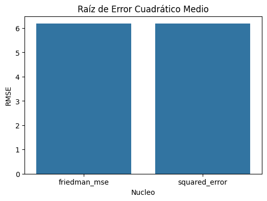

```python
imp_grafico_rmse(resultados_gb)
```

## Parte 2

- b) Construya un DataFrame que compare los modelos generados en elítem anterior. Para esto en cada una de las filas debe aparecer un modelo predictivo y en las columnas aparezcan el índice de Raíz del error cuadrático medio e interprete los resultados. >Cuál de los modelos es mejor para estos datos y por qué?, recuerde comparar contra el resumen numérico de la variable a predecir.

↑ Volver al Menú

```python
kfold = KFold(n_splits = 10, shuffle = True)
rmse_reg      = 0
rmse_lasso    = 0
rmse_ridge    = 0
rmse_svm      = 0
rmse_arboles  = 0
rmse_bosques  = 0
rmse_potencia = 0

for train, test in kfold.split(X, y):
  tam_test = y[test].size

  # Regresión
  modelo = Pipeline(steps=[
    ('preprocesador', preprocesamiento),
    ('clasificador', LinearRegression())
  ])
  noimprimir  = modelo.fit(X.iloc[train], y[train])
  pred_fold   = modelo.predict(X.iloc[test])
  rmse_reg = rmse_reg + np.sqrt((1/tam_test)*np.sum(np.square(y[test] - pred_fold)))

  # Lasso
  modelo = Pipeline(steps=[
    ('preprocesador', preprocesamiento),
    ('clasificador', Lasso(alpha = mejor_alfa))
  ])
  noimprimir = modelo.fit(X.iloc[train], y[train])
  pred_fold  = modelo.predict(X.iloc[test])
  rmse_lasso = rmse_lasso + np.sqrt((1/tam_test)*np.sum(np.square(y[test] - pred_fold)))

  # Ridge
  modelo = Pipeline(steps=[
    ('preprocesador', preprocesamiento),
    ('clasificador', Ridge(alpha = best_alpha_ridge, solver = "svd"))

  ])
  noimprimir = modelo.fit(X.iloc[train], y[train])
  pred_fold  = modelo.predict(X.iloc[test])
  rmse_ridge = rmse_ridge + np.sqrt((1/tam_test)*np.sum(np.square(y[test] - pred_fold)))

  # SVM
  modelo = Pipeline(steps=[
    ('preprocesador', preprocesamiento),
    ('clasificador', SVR(kernel = 'rbf', C=100, epsilon=0.1))
  ])
  noimprimir = modelo.fit(X.iloc[train], y[train])
  pred_fold  = modelo.predict(X.iloc[test])
  rmse_svm = rmse_svm + np.sqrt((1/tam_test)*np.sum(np.square(y[test] - pred_fold)))

  # Árboles
  modelo = Pipeline(steps=[
    ('preprocesador', preprocesamiento),
    ('clasificador', DecisionTreeRegressor(max_depth = 3, criterion = "squared_error"))
  ])
  noimprimir = modelo.fit(X.iloc[train], y[train])
  pred_fold  = modelo.predict(X.iloc[test])
  rmse_arboles = rmse_arboles + np.sqrt((1/tam_test)*np.sum(np.square(y[test] - pred_fold)))

  # Bosques Aleatorios
  modelo = Pipeline(steps=[
    ('preprocesador', preprocesamiento),
    ('clasificador', RandomForestRegressor(max_depth=20, n_estimators = 40, criterion = "absolute_error"))
    ])
  noimprimir = modelo.fit(X.iloc[train], y[train])
  pred_fold  = modelo.predict(X.iloc[test])
  rmse_bosques = rmse_bosques + np.sqrt((1/tam_test)*np.sum(np.square(y[test] - pred_fold)))

  # Potenciación
  modelo = Pipeline(steps=[
    ('preprocesador', preprocesamiento),
    ('clasificador', GradientBoostingRegressor(n_estimators = 40, max_depth = 3, criterion= "squared_error"))
  ])
  noimprimir = modelo.fit(X.iloc[train], y[train])
  pred_fold  = modelo.predict(X.iloc[test])
  rmse_potencia = rmse_potencia + np.sqrt((1/tam_test)*np.sum(np.square(y[test] - pred_fold)))

# Se debe promediar el error cometido en los 10 grupos,
# se divide entre 10 pues n_splits = 10
rmse_reg = rmse_reg / 10
rmse_lasso = rmse_lasso / 10
rmse_ridge = rmse_ridge / 10
rmse_svm = rmse_svm / 10
rmse_arboles = rmse_arboles / 10
rmse_bosques = rmse_bosques / 10
rmse_potencia = rmse_potencia / 10
```

```python
res = pd.DataFrame({
  'Modelo': ['Regresion', 'Lasso', 'Ridge', 'SVM', 'Arboles', 'Bosques', 'Potenciacion'],
  'RMSE': [rmse_reg, rmse_lasso, rmse_ridge, rmse_svm, rmse_arboles, rmse_bosques, rmse_potencia]
})
res
```

|  | Modelo | RMSE |
| --- | --- | --- |
| 0 | Regresion | 10.451901 |
| 1 | Lasso | 10.472273 |
| 2 | Ridge | 10.451853 |
| 3 | SVM | 5.603120 |
| 4 | Arboles | 10.339009 |
| 5 | Bosques | 4.896570 |
| 6 | Potenciacion | 6.216148 |

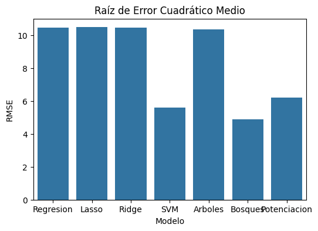

```python
fig, ax = plt.subplots(figsize = (6, 4))
sns.barplot(x = 'Modelo', y = 'RMSE', data = res)
plt.title("Raíz de Error Cuadrático Medio")
plt.show()
```

**Interpretacion**

- Al comparar los modelos anteriores de regresion, denotamos que como el "calcular el valor de resistencia de compresión del concreto" el modelo que tuvo un mejor desempe;o fue `RandomForestRegressor` de los modelos anteriores, es el que tiene el indice mas bajo de error.

| Modelo | RMSE |
| --- | --- |
| RandomForestRegressor | 4.896570 |

## Parte 3

- c) Guarde el mejor modelo en un archivo.

↑ Volver al Menú

```python
modelo_regressor = Pipeline(steps=[
    ('preprocesador', preprocesamiento),
    ('clasificador', RandomForestRegressor(max_depth=20, n_estimators = 40, criterion = "absolute_error"))
])
noimprimir = modelo_regressor.fit(X, y)
```

```python
import pickle

with open("modelo_RandomForestRegressor.pkl", 'wb') as file:
  pickle.dump(modelo_regressor, file)
```